# Appendix to Chapter 10

M. Sonderegger

14/01/22

This document fits models used in Chapter 10 of *Regression Modeling for Linguistic Data*, and fills out some sections with more detail (e.g. full model summaries).

Note that some models are fitted with `evaluate()` calls (from the ‘evaluate’ package), which save the model’s output in a way that lets me recreate warnings/messages in fitting in the text of Chapter 10 (the `replay()` calls), without having to actually rerun the models. See comments in the Rnw file code, around line 50, for more detail.

If you are using this Rmd file in isolation, you could just fit the models without the `evaluate()`/`replay()` calls (e.g. run `set.seed(101)` instead of `t1 <- evaluate("set.seed(101); replay(t1)")`.

# 1 Preliminaries

Load packages, set default contrasts to Helmert, explicitly set contrasts for factors, load datasets (see beginning of Chapter 10 for context):

```r
library(tidyverse)
library(broom)
library(arm)
library(lme4)
library(car)
library(broom.mixed)
library(languageR)
library(evaluate)
```

```r
# default contrasts = helmert
options(contrasts = c("contr.helmert", "contr.poly"))

vot <- read.csv("data/vot_rmld.csv", stringsAsFactors = TRUE)  %>%
    # relevel place to be labial < alveolar < velar
  mutate(place=fct_relevel(place, "labial")) %>%
  mutate(log_corpus_freq = rescale(log_corpus_freq),
         speaking_rate_dev = rescale(speaking_rate_dev),
         ## yes > no
         foll_high_vowel = rescale(foll_high_vowel),
         ## yes > no
         cons_cluster = rescale(cons_cluster),
         # male > female
         gender = rescale(gender),
         ## stressed > unstress
         stress = rescale(stress))

contrasts(vot$place) <- contr.helmert(3)

diatones <- read.csv("data/diatones_rmld.csv", stringsAsFactors = TRUE) %>%
  mutate(
    syll1_coda_orig = syll1_coda,
    syll2_coda_orig = syll2_coda,
    syll2_td_orig = syll2_td,
    ## turns no/yes -> 0/1, then center
    syll1_coda = rescale(syll1_coda_orig),
    ## code '0'/'C'/'CC'/'CCC' as ordered factor-> 0/1/2/3,
    ## then standardize
    syll2_coda = rescale(str_count(syll2_coda_orig, "C")),
    syll2_td = rescale(syll2_td_orig),
    frequency = rescale(frequency)
  )

neutralization <- read.csv('data/neutralization_rmld.csv',
  stringsAsFactors = TRUE) %>%
  ## factor version of voicing, with voiceless < voiced
  mutate(voicing_fact = fct_relevel(voicing, 'voiceless'))

neutralization <- neutralization %>% filter(!is.na(prosodic_boundary))

neutralization <-
  mutate(neutralization,
         prosodic_boundary = rescale(prosodic_boundary),
         ## voiced > voiceless
         voicing = rescale(voicing_fact),
         ## make sure grouping factors are factors
         item_pair = as.factor(item_pair),
         subject=as.factor(subject)
  )

# Explicitly set contrasts, as discussed at beginning of Chapter 8
contrasts(neutralization$voicing_fact) <- contr.helmert(2)
contrasts(neutralization$place) <- contr.helmert(3)
contrasts(neutralization$vowel) <- contr.helmert(5)


givenness <- read.csv('data/givenness_rmld.csv', stringsAsFactors = TRUE) %>%
  mutate(
    clabel.williams = arm::rescale(conditionLabel),
    npType.pronoun = arm::rescale(npType),
    voice.passive = arm::rescale(voice),
    order.std = arm::rescale(order),
    shifted = (as.numeric(stressshift) - 1),
    ## make sure that grouping factors are factors
    item = as.factor(item),
    participant=as.factor(participant)
  )

turkish_if0 <- read.csv("data/turkish_if0_rmld.csv", stringsAsFactors = TRUE)

## redefine contrast matrix for basevowel
contrMat <- matrix(c(-2/3, 1/3, 1/3, 0, -1/2, 1/2), ncol=2)
rownames(contrMat) <- c('A','I','U')
colnames(contrMat) <- c('AvIU', 'IvU')
contrasts(turkish_if0$base_vowel) <- contrMat

## standardize predictors
turkish_if0 <- turkish_if0 %>%
  mutate(utterance_num_syllables = arm::rescale(utterance_num_syllables),
         speaker_mean_f0 = arm::rescale(speaker_mean_f0),
         ## voiceless = pos, voiced = neg
         Voicing.vl = arm::rescale(Voicing),
         ## male = pos, female = neg
         gender.male=arm::rescale(gender),
         arm::rescale(local_f0)
  )
```

# 2 Convergence: problems with the data or model

## 2.1 diatones: problem with the data

The original model was:

```r
diatones_melr <- glmer(formula = stress_shifted ~ syll2_coda +
syll2_td + frequency + syll1_coda + syll2_td:frequency +
  frequency:syll1_coda + (1|prefix), family = "binomial", data = diatones)
summary(diatones_melr, correlation=FALSE)
```

```
## Generalized linear mixed model fit by maximum likelihood (Laplace
##   Approximation) [glmerMod]
##  Family: binomial  ( logit )
## Formula: stress_shifted ~ syll2_coda + syll2_td + frequency + syll1_coda +
##     syll2_td:frequency + frequency:syll1_coda + (1 | prefix)
##    Data: diatones
##
##      AIC      BIC   logLik deviance df.resid
##    109.3    132.3    -46.7     93.3      122
##
## Scaled residuals:
##     Min      1Q  Median      3Q     Max
## -1.0551 -0.4249 -0.2162 -0.0931  5.5846
##
## Random effects:
##  Groups Name        Variance Std.Dev.
##  prefix (Intercept) 1.946    1.395
## Number of obs: 130, groups:  prefix, 13
##
## Fixed effects:
##                      Estimate Std. Error z value Pr(>|z|)
## (Intercept)           -2.2522     0.6618  -3.403 0.000667 ***
## syll2_coda            -1.9932     0.8755  -2.277 0.022799 *
## syll2_td               1.9327     0.8627   2.240 0.025070 *
## frequency             -0.8575     0.6421  -1.335 0.181761
## syll1_coda             2.3984     1.2925   1.856 0.063502 .
## syll2_td:frequency     2.9646     1.3739   2.158 0.030947 *
## frequency:syll1_coda   4.3836     1.9392   2.260 0.023790 *
## ---
## Signif. codes:  0 '***' 0.001 '**' 0.01 '*' 0.05 '.' 0.1 ' ' 1
```

Refit this model with the version of the `syll2_coda` predictor which is a factor with 4 levels:

```r
levels(diatones$syll2_coda_orig)
```

```
## [1] "0"   "C"   "CC"  "CCC"
```

```r
diatones_melr_bad_eval <- evaluate("diatones_melr_bad <- update(diatones_melr, . ~ . - syll2_coda + syll2_coda_orig)")
replay(diatones_melr_bad_eval)
```

```
## > diatones_melr_bad <- update(diatones_melr, . ~ . - syll2_coda + syll2_coda_orig)
```

This model doesn’t converge. The fixed-effect estimates suggest why (separable data):

```r
summary(diatones_melr_bad, correlation=FALSE)
```

```
## Generalized linear mixed model fit by maximum likelihood (Laplace
##   Approximation) [glmerMod]
##  Family: binomial  ( logit )
## Formula: stress_shifted ~ syll2_td + frequency + syll1_coda + (1 | prefix) +
##     syll2_coda_orig + syll2_td:frequency + frequency:syll1_coda
##    Data: diatones
##
##      AIC      BIC   logLik deviance df.resid
##    107.8    136.5    -43.9     87.8      120
##
## Scaled residuals:
##     Min      1Q  Median      3Q     Max
## -1.1393 -0.3925 -0.1860 -0.0322  3.9305
##
## Random effects:
##  Groups Name        Variance Std.Dev.
##  prefix (Intercept) 4.207    2.051
## Number of obs: 130, groups:  prefix, 13
##
## Fixed effects:
##                       Estimate Std. Error z value Pr(>|z|)
## (Intercept)            -6.2347  2226.1864  -0.003  0.99777
## syll2_td                2.7244     1.0151   2.684  0.00728 **
## frequency              -1.3250     0.6939  -1.910  0.05618 .
## syll1_coda              3.7265     1.3931   2.675  0.00747 **
## syll2_coda_orig1       -2.1388     0.6954  -3.076  0.00210 **
## syll2_coda_orig2       -0.8964     0.3557  -2.520  0.01174 *
## syll2_coda_orig3       -4.4651  2226.1862  -0.002  0.99840
## syll2_td:frequency      4.0457     1.5029   2.692  0.00710 **
## frequency:syll1_coda    6.1214     2.4072   2.543  0.01099 *
## ---
## Signif. codes:  0 '***' 0.001 '**' 0.01 '*' 0.05 '.' 0.1 ' ' 1
## optimizer (Nelder_Mead) convergence code: 0 (OK)
## unable to evaluate scaled gradient
## Model failed to converge: degenerate  Hessian with 1 negative eigenvalues
```

## 2.2 vot: problem with model specification

Subset of the VOT data used in Chapter 8:

```r
core_speakers <- c("dale", "darnell", "lisa", "luke", "michael",
                       "mohamed", "rachel", "rebecca", "rex", "sara", "stuart")

vot_voiced_core <- vot %>%
  filter(syll_length==1 & speaker %in% core_speakers &
           voicing=='voiced') %>% droplevels()
```

The final model fitted to this data in Chapter 8 was:

```r
vot_mod3 <- lmer(log_vot ~ speaking_rate_dev + foll_high_vowel + cons_cluster +
    log_corpus_freq + place + gender + (1 | word) + (1 + speaking_rate_dev |
    speaker), data=vot_voiced_core
)
```

A model with by-speaker and (incorrectly) by-word random slopes for `place` is:

```r
vot_mod3_bad_eval <- evaluate("vot_mod3_bad <- lmer(log_vot ~ speaking_rate_dev + foll_high_vowel + cons_cluster +
  log_corpus_freq + place + gender +
(1+speaking_rate_dev+place|speaker) + (1+place|word), data=vot_voiced_core)")
replay(vot_mod3_bad_eval)
```

```
## > vot_mod3_bad <- lmer(log_vot ~ speaking_rate_dev + foll_high_vowel + cons_cluster +
## +   log_corpus_freq + place + gender +
## + (1+speaking_rate_dev+place|speaker) + (1+place|word), data=vot_voiced_core)
```

Note that nothing in the model output suggests the problem:

```r
summary(vot_mod3_bad, correlation=FALSE)
```

```
## Linear mixed model fit by REML ['lmerMod']
## Formula: log_vot ~ speaking_rate_dev + foll_high_vowel + cons_cluster +
##     log_corpus_freq + place + gender + (1 + speaking_rate_dev +
##     place | speaker) + (1 + place | word)
##    Data: vot_voiced_core
##
## REML criterion at convergence: 12060.4
##
## Scaled residuals:
##     Min      1Q  Median      3Q     Max
## -4.3263 -0.5629  0.0649  0.6514  3.3533
##
## Random effects:
##  Groups   Name              Variance  Std.Dev. Corr
##  word     (Intercept)       0.0006272 0.02504
##           place1            0.0176774 0.13296   0.53
##           place2            0.0025061 0.05006  -0.98 -0.35
##  speaker  (Intercept)       0.0417213 0.20426
##           speaking_rate_dev 0.0030769 0.05547   0.71
##           place1            0.0283846 0.16848  -0.14  0.02
##           place2            0.0019352 0.04399  -0.30 -0.07 -0.75
##  Residual                   0.3039879 0.55135
## Number of obs: 7175, groups:  word, 272; speaker, 11
##
## Fixed effects:
##                   Estimate Std. Error t value
## (Intercept)        2.62960    0.06486  40.540
## speaking_rate_dev -0.03220    0.02132  -1.510
## foll_high_vowel    0.06717    0.03412   1.968
## cons_cluster       0.43176    0.03783  11.412
## log_corpus_freq    0.04797    0.03743   1.282
## place1             0.32640    0.05514   5.919
## place2             0.12347    0.01717   7.190
## gender            -0.37056    0.08453  -4.384
## optimizer (nloptwrap) convergence code: 0 (OK)
## Model failed to converge with max|grad| = 0.00297106 (tol = 0.002, component 1)
```

Refitting the model without this term (and changing the optimizer, necessary for convergence):

```r
vot_mod3_placeRanef <-lmer(log_vot ~ speaking_rate_dev + foll_high_vowel + cons_cluster +
  log_corpus_freq + place + gender +
(1+speaking_rate_dev+place|speaker) + (1|word), control=lmerControl(optimizer = "bobyqa"), data=vot_voiced_core)

summary(vot_mod3_placeRanef, correlation=FALSE)
```

```
## Linear mixed model fit by REML ['lmerMod']
## Formula: log_vot ~ speaking_rate_dev + foll_high_vowel + cons_cluster +
##     log_corpus_freq + place + gender + (1 + speaking_rate_dev +
##     place | speaker) + (1 | word)
##    Data: vot_voiced_core
## Control: lmerControl(optimizer = "bobyqa")
##
## REML criterion at convergence: 12063.9
##
## Scaled residuals:
##     Min      1Q  Median      3Q     Max
## -4.3276 -0.5641  0.0625  0.6504  3.3514
##
## Random effects:
##  Groups   Name              Variance Std.Dev. Corr
##  word     (Intercept)       0.014709 0.12128
##  speaker  (Intercept)       0.041693 0.20419
##           speaking_rate_dev 0.003075 0.05545   0.70
##           place1            0.028399 0.16852  -0.14  0.02
##           place2            0.001932 0.04395  -0.31 -0.07 -0.74
##  Residual                   0.304266 0.55160
## Number of obs: 7175, groups:  word, 272; speaker, 11
##
## Fixed effects:
##                   Estimate Std. Error t value
## (Intercept)        2.61797    0.06476  40.428
## speaking_rate_dev -0.03183    0.02133  -1.492
## foll_high_vowel    0.08159    0.03510   2.325
## cons_cluster       0.46297    0.03974  11.650
## log_corpus_freq    0.03693    0.03744   0.986
## place1             0.31939    0.05421   5.892
## place2             0.12453    0.01767   7.048
## gender            -0.36769    0.08531  -4.310
```

# 3 Convergence: optimization problems

Refit the VOT model, but now for *all* speakers, all words with `voicing`=voiced. This includes words with multiple syllables, so we now need the `stress` predictor, which we omitted when fitting `vot_mod3` because it has the same value for all single-syllable words.

This model does not converge:

```r
vot_voiced <- filter(vot, voicing=='voiced')

vot_mod3_full_eval <- evaluate("vot_mod3_full <- update(vot_mod3, . ~ . + stress, data=vot_voiced)")
replay(vot_mod3_full_eval)
```

```
## > vot_mod3_full <- update(vot_mod3, . ~ . + stress, data=vot_voiced)
```

## 3.1 Changing start values

We can simply restart the fit from the original values:

```r
fittedVals <- getME(vot_mod3_full,"theta")
  vot_mod3_full_1_eval <-
    evaluate("vot_mod3_full_1 <- update(vot_mod3_full, start=fittedVals)")
  replay(vot_mod3_full_1_eval)
```

```
## > vot_mod3_full_1 <- update(vot_mod3_full, start=fittedVals)
```

Or slightly perturbed values:

```r
set.seed(101)
 pars<- getME(vot_mod3_full,"theta")
fittedVals_perturbed <- runif(length(pars),pars/1.01,pars*1.01)
fittedVals_perturbed <- runif(length(pars),pars/1.01,pars*1.01)*sign(pars)
# sign(pars) makes this work when some fixed effects are negative
  vot_mod3_full_2_eval <- evaluate("vot_mod3_full_2 <- update(vot_mod3_full, start=fittedVals_perturbed)")
  replay(vot_mod3_full_2_eval)
```

```
## > vot_mod3_full_2 <- update(vot_mod3_full, start=fittedVals_perturbed)
```

Either way, we get an identical model to the one that didn’t converge. To check this, examine the log-likelihood and fixed effects (faster than examining for each model):

```r
logLik(vot_mod3_full_1)
```

```
## 'log Lik.' -11222.31 (df=14)
```

```r
logLik(vot_mod3_full)
```

```
## 'log Lik.' -11222.31 (df=14)
```

```r
compareCoefs(vot_mod3_full_1, vot_mod3_full, zvals = TRUE)
```

```
## Calls:
## 1: lmer(formula = log_vot ~ speaking_rate_dev + foll_high_vowel +
##   cons_cluster + log_corpus_freq + place + gender + (1 | word) + (1 +
##   speaking_rate_dev | speaker) + stress, data = vot_voiced, start =
##   fittedVals)
## 2: lmer(formula = log_vot ~ speaking_rate_dev + foll_high_vowel +
##   cons_cluster + log_corpus_freq + place + gender + (1 | word) + (1 +
##   speaking_rate_dev | speaker) + stress, data = vot_voiced)
##
##                   Model 1 Model 2
## (Intercept)        2.6179  2.6179
## SE                 0.0524  0.0524
## z                   49.99   49.99
##
## speaking_rate_dev -0.0552 -0.0552
## SE                 0.0172  0.0172
## z                   -3.21   -3.21
##
## foll_high_vowel    0.0853  0.0853
## SE                 0.0235  0.0235
## z                    3.62    3.62
##
## cons_cluster       0.5082  0.5082
## SE                 0.0285  0.0285
## z                   17.80   17.80
##
## log_corpus_freq    0.0287  0.0287
## SE                 0.0242  0.0242
## z                    1.19    1.19
##
## place1             0.3190  0.3190
## SE                 0.0119  0.0119
## z                   26.81   26.81
##
## place2             0.1254  0.1254
## SE                 0.0086  0.0086
## z                   14.57   14.57
##
## gender            -0.2377 -0.2377
## SE                 0.0852  0.0852
## z                   -2.79   -2.79
##
## stress            -0.0294 -0.0294
## SE                 0.0334  0.0334
## z                   -0.88   -0.88
##
```

(Technically we should examine the random effect estimates as well.)

## 3.2 Decrease stopping tolerances

We could alternatively decrease the optimizer’s stopping tolerances (see `?convergence`):

```r
strict_tol <- lmerControl(optCtrl=list(xtol_abs=1e-8, ftol_abs=1e-8))

## refit the model with these tolerances
vot_mod3_full_3_eval <- evaluate("vot_mod3_full_3 <- update(vot_mod3_full, control=strict_tol)")
replay(vot_mod3_full_3_eval)
```

```
## > vot_mod3_full_3 <- update(vot_mod3_full, control=strict_tol)
```

This does converge, and again gives the same fit:

```r
logLik(vot_mod3_full_2)
```

```
## 'log Lik.' -11222.31 (df=14)
```

```r
logLik(vot_mod3_full)
```

```
## 'log Lik.' -11222.31 (df=14)
```

```r
compareCoefs(vot_mod3_full_2, vot_mod3_full, zvals = TRUE)
```

```
## Calls:
## 1: lmer(formula = log_vot ~ speaking_rate_dev + foll_high_vowel +
##   cons_cluster + log_corpus_freq + place + gender + (1 | word) + (1 +
##   speaking_rate_dev | speaker) + stress, data = vot_voiced, start =
##   fittedVals_perturbed)
## 2: lmer(formula = log_vot ~ speaking_rate_dev + foll_high_vowel +
##   cons_cluster + log_corpus_freq + place + gender + (1 | word) + (1 +
##   speaking_rate_dev | speaker) + stress, data = vot_voiced)
##
##                   Model 1 Model 2
## (Intercept)        2.6179  2.6179
## SE                 0.0524  0.0524
## z                   49.99   49.99
##
## speaking_rate_dev -0.0552 -0.0552
## SE                 0.0172  0.0172
## z                   -3.21   -3.21
##
## foll_high_vowel    0.0853  0.0853
## SE                 0.0235  0.0235
## z                    3.62    3.62
##
## cons_cluster       0.5082  0.5082
## SE                 0.0285  0.0285
## z                   17.80   17.80
##
## log_corpus_freq    0.0287  0.0287
## SE                 0.0242  0.0242
## z                    1.19    1.19
##
## place1             0.3190  0.3190
## SE                 0.0119  0.0119
## z                   26.81   26.81
##
## place2             0.1254  0.1254
## SE                 0.0086  0.0086
## z                   14.57   14.57
##
## gender            -0.2378 -0.2377
## SE                 0.0852  0.0852
## z                   -2.79   -2.79
##
## stress            -0.0294 -0.0294
## SE                 0.0334  0.0334
## z                   -0.88   -0.88
##
```

## 3.3 Increasing iterations

The maximum number of iterations is another parameter that can be increased for a more accurate fit, at the expense of the model possibly taking longer to run.

For example, consider our model of the data from the last chapter, now fitted with maximal random effect structure (all possible slopes, correlations):

```r
giv_maximal_bad_eval <- evaluate("giv_maximal <- glmer(stressshift ~ clabel.williams*voice.passive +
npType.pronoun + (1+clabel.williams+ npType.pronoun|item) +
(1 +clabel.williams*voice.passive + npType.pronoun |participant),
data=givenness, family='binomial', control=glmerControl(optimizer = 'bobyqa'))")
replay(giv_maximal_bad_eval)
```

```
## > giv_maximal <- glmer(stressshift ~ clabel.williams*voice.passive +
## + npType.pronoun + (1+clabel.williams+ npType.pronoun|item) +
## + (1 +clabel.williams*voice.passive + npType.pronoun |participant),
## + data=givenness, family='binomial', control=glmerControl(optimizer = 'bobyqa'))
```

```
## boundary (singular) fit: see ?isSingular
```

This doesn’t converge in the default maximum number of iterations:

```r
giv_maximal@optinfo$feval ## maximum iterations = 10000
```

```
## [1] 10000
```

If we increase this parameter, the model converges:

```r
# change maximum iterations to 100000
giv_maximal <- update(giv_maximal,
control=glmerControl(optimizer = "bobyqa", optCtrl=list(maxfun=100000)))
```

```
## boundary (singular) fit: see ?isSingular
```

```r
giv_maximal@optinfo$feval ## iterations to convergence
```

```
## [1] 21536
```

# 4 Convergence: standardizing predictors

Consider the new VOT model from above `vot_mod_full`, but now fitted with maximal random effect structure. First, suppose we tried to fit this model with non-standardized predictors: all continuous variables not centered or scaled, and all factors with treatment coding:

```r
## load the data
vot_unstd <- read.csv("data/vot_rmld.csv", stringsAsFactors = TRUE)  %>%
    # relevel place to be labial < alveolar < velar
  mutate(place=fct_relevel(place, "labial"))

## because factors have Helmert coding by default, we have to reset all factors to treatment coding:

contrasts(vot_unstd$foll_high_vowel) <- contr.treatment(2)
contrasts(vot_unstd$cons_cluster) <- contr.treatment(2)
contrasts(vot_unstd$place) <- contr.treatment(3)
contrasts(vot_unstd$gender) <- contr.treatment(2)
contrasts(vot_unstd$stress) <- contr.treatment(2)

## fit the model:
system.time(
  vot_mod_maximal_unstd <- lmer(log_vot ~ speaking_rate_dev + foll_high_vowel + cons_cluster +  log_corpus_freq + place + gender + stress +
                                  (1 + gender + speaking_rate_dev |  word) +
                                  (1 + speaking_rate_dev + foll_high_vowel + cons_cluster +  log_corpus_freq + place + stress| speaker), data=filter(vot_unstd, voicing=='voiced')
  )
)
```

```
##    user  system elapsed
## 121.226   0.541 121.907
```

```r
summary(vot_mod_maximal_unstd, correlation=FALSE)
```

```
## Linear mixed model fit by REML ['lmerMod']
## Formula: log_vot ~ speaking_rate_dev + foll_high_vowel + cons_cluster +
##     log_corpus_freq + place + gender + stress + (1 + gender +
##     speaking_rate_dev | word) + (1 + speaking_rate_dev + foll_high_vowel +
##     cons_cluster + log_corpus_freq + place + stress | speaker)
##    Data: filter(vot_unstd, voicing == "voiced")
##
## REML criterion at convergence: 21832
##
## Scaled residuals:
##     Min      1Q  Median      3Q     Max
## -4.2640 -0.5549  0.0662  0.6508  3.5452
##
## Random effects:
##  Groups   Name              Variance  Std.Dev. Corr
##  word     (Intercept)       0.0117430 0.10837
##           gender2           0.0053749 0.07331  -0.39
##           speaking_rate_dev 0.0003619 0.01902   0.09  0.02
##  speaker  (Intercept)       0.0667575 0.25837
##           speaking_rate_dev 0.0005276 0.02297   0.30
##           foll_high_vowel2  0.0030405 0.05514  -0.23  0.52
##           cons_cluster2     0.0221750 0.14891  -0.07  0.60  0.23
##           log_corpus_freq   0.0001987 0.01410  -0.25  0.37  0.14  0.70
##           place2            0.0727586 0.26974  -0.50 -0.08  0.16  0.43  0.83
##           place3            0.0139984 0.11832  -0.81 -0.25  0.05  0.45  0.28
##           stress2           0.0076205 0.08730  -0.13  0.16  0.03 -0.42 -0.22
##  Residual                   0.3065152 0.55364
##
##
##
##
##
##
##
##
##
##
##   0.45
##  -0.46 -0.28
##
## Number of obs: 12908, groups:  word, 788; speaker, 20
##
## Fixed effects:
##                    Estimate Std. Error t value
## (Intercept)        2.192080   0.077429  28.311
## speaking_rate_dev -0.021553   0.007317  -2.946
## foll_high_vowel2   0.070257   0.025962   2.706
## cons_cluster2      0.499706   0.044942  11.119
## log_corpus_freq    0.005968   0.006199   0.963
## place2             0.650232   0.065758   9.888
## place3             0.685893   0.037737  18.176
## gender2           -0.189170   0.062312  -3.036
## stress2           -0.029448   0.038668  -0.762
## optimizer (nloptwrap) convergence code: 0 (OK)
## Model failed to converge with max|grad| = 0.0424372 (tol = 0.002, component 1)
```

This model does not converge, but refitting with *standardized* predictors, it does:

```r
system.time(
  vot_mod_maximal <- lmer(log_vot ~ speaking_rate_dev + foll_high_vowel + cons_cluster +  log_corpus_freq + place + gender +  stress +
                            (1 + gender + speaking_rate_dev |  word) +
                            (1 + speaking_rate_dev + foll_high_vowel + cons_cluster +  log_corpus_freq + place + stress| speaker), data=vot_voiced)
)
```

```
## boundary (singular) fit: see ?isSingular
```

```
##    user  system elapsed
## 130.048   0.571 130.716
```

```r
summary(vot_mod_maximal, correlation=FALSE)
```

```
## Linear mixed model fit by REML ['lmerMod']
## Formula: log_vot ~ speaking_rate_dev + foll_high_vowel + cons_cluster +
##     log_corpus_freq + place + gender + stress + (1 + gender +
##     speaking_rate_dev | word) + (1 + speaking_rate_dev + foll_high_vowel +
##     cons_cluster + log_corpus_freq + place + stress | speaker)
##    Data: vot_voiced
##
## REML criterion at convergence: 21827.3
##
## Scaled residuals:
##     Min      1Q  Median      3Q     Max
## -4.2624 -0.5546  0.0663  0.6515  3.5427
##
## Random effects:
##  Groups   Name              Variance Std.Dev. Corr
##  word     (Intercept)       0.009992 0.09996
##           gender            0.005378 0.07333  0.03
##           speaking_rate_dev 0.002113 0.04597  0.11  0.02
##  speaker  (Intercept)       0.060680 0.24633
##           speaking_rate_dev 0.003024 0.05500   0.61
##           foll_high_vowel   0.003034 0.05508  -0.07  0.53
##           cons_cluster      0.022284 0.14928   0.16  0.62  0.23
##           log_corpus_freq   0.003620 0.06017   0.12  0.39  0.14  0.70
##           placealveolar     0.072697 0.26962  -0.29 -0.07  0.16  0.43  0.83
##           placevelar        0.013849 0.11768  -0.79 -0.24  0.05  0.45  0.27
##           stress            0.007412 0.08610   0.08  0.17  0.03 -0.43 -0.24
##  Residual                   0.306538 0.55366
##
##
##
##
##
##
##
##
##
##
##   0.45
##  -0.46 -0.30
##
## Number of obs: 12908, groups:  word, 788; speaker, 20
##
## Fixed effects:
##                   Estimate Std. Error t value
## (Intercept)        2.17946    0.05946  36.654
## speaking_rate_dev -0.05210    0.01758  -2.964
## foll_high_vowel    0.07020    0.02595   2.705
## cons_cluster       0.49968    0.04501  11.102
## log_corpus_freq    0.02547    0.02644   0.964
## placealveolar      0.65028    0.06574   9.892
## placevelar         0.68581    0.03763  18.226
## gender            -0.18872    0.06180  -3.054
## stress            -0.02968    0.03850  -0.771
## optimizer (nloptwrap) convergence code: 0 (OK)
## boundary (singular) fit: see ?isSingular
```

# 5 Convergence: Changing the optimizer

Our model of the `givenness` data from Chapter 9 was:

```r
givenness_m1 <- glmer(stressshift ~ clabel.williams*voice.passive+npType.pronoun +
                  (1 + clabel.williams +npType.pronoun||item) +
                  (1 + clabel.williams*voice.passive + +npType.pronoun||participant),
                data=givenness,
                family="binomial",
                control=glmerControl(optimizer = "bobyqa"))
```

```
## boundary (singular) fit: see ?isSingular
```

We needed to change the optimizer from the default to make it converge:

```r
givenness_m1 <- glmer(stressshift ~ clabel.williams*voice.passive+npType.pronoun +
                  (1 + clabel.williams +npType.pronoun||item) +
                  (1 + clabel.williams*voice.passive + +npType.pronoun||participant),
                data=givenness,
                family="binomial")
```

Refit the model using all possible optimizers:

```r
giv_m1.all <- allFit(givenness_m1)
```

```
## bobyqa :
```

```
## boundary (singular) fit: see ?isSingular
```

```
## [OK]
## Nelder_Mead :
```

```
## boundary (singular) fit: see ?isSingular
```

```
## [OK]
## nlminbwrap :
```

```
## boundary (singular) fit: see ?isSingular
```

```
## [OK]
## nmkbw :
```

```
## [OK]
## optimx.L-BFGS-B :
```

```
## boundary (singular) fit: see ?isSingular
```

```
## [OK]
## nloptwrap.NLOPT_LN_NELDERMEAD :
```

```
## boundary (singular) fit: see ?isSingular
```

```
## [OK]
## nloptwrap.NLOPT_LN_BOBYQA :
```

```
## boundary (singular) fit: see ?isSingular
```

```
## [OK]
```

This object contains elements comparing the models’ fixed effects, likelihoods, convergence messages, etc. (see `?allFit`)

```r
summary(giv_m1.all)
```

```
## $which.OK
##                        bobyqa                   Nelder_Mead
##                          TRUE                          TRUE
##                    nlminbwrap                         nmkbw
##                          TRUE                          TRUE
##               optimx.L-BFGS-B nloptwrap.NLOPT_LN_NELDERMEAD
##                          TRUE                          TRUE
##     nloptwrap.NLOPT_LN_BOBYQA
##                          TRUE
##
## $msgs
## $msgs$bobyqa
## [1] "boundary (singular) fit: see ?isSingular"
##
## $msgs$Nelder_Mead
## [1] "boundary (singular) fit: see ?isSingular"
##
## $msgs$nlminbwrap
## [1] "boundary (singular) fit: see ?isSingular"
##
## $msgs$nmkbw
## [1] "Model failed to converge with max|grad| = 0.00210497 (tol = 0.002, component 1)"
##
## $msgs$`optimx.L-BFGS-B`
## [1] "boundary (singular) fit: see ?isSingular"
##
## $msgs$nloptwrap.NLOPT_LN_NELDERMEAD
## [1] "boundary (singular) fit: see ?isSingular"
##
## $msgs$nloptwrap.NLOPT_LN_BOBYQA
## [1] "boundary (singular) fit: see ?isSingular"
##
##
## $fixef
##                               (Intercept) clabel.williams voice.passive
## bobyqa                          -1.184045        4.025930     0.4068640
## Nelder_Mead                     -1.186421        4.029677     0.4056508
## nlminbwrap                      -1.184042        4.025909     0.4068740
## nmkbw                           -1.184002        4.025890     0.4068730
## optimx.L-BFGS-B                 -1.183969        4.025857     0.4068459
```

[output cut: 128 more lines]

```
## nloptwrap.NLOPT_LN_NELDERMEAD     2.159    0.006   2.168          0         0
## nloptwrap.NLOPT_LN_BOBYQA         0.917    0.001   0.920          0         0
##
## $feval
##                        bobyqa                   Nelder_Mead
##                           802                          4817
##                    nlminbwrap                         nmkbw
##                            NA                           920
##               optimx.L-BFGS-B nloptwrap.NLOPT_LN_NELDERMEAD
##                            42                           701
##     nloptwrap.NLOPT_LN_BOBYQA
##                           223
##
## attr(,"class")
## [1] "summary.allFit"
```

For example, to examine just the log-likelihoods and fixed effects of the models fitted with each optimizer:

```r
summary(giv_m1.all)$llik
```

```
##                        bobyqa                   Nelder_Mead
##                     -159.6519                     -159.6526
##                    nlminbwrap                         nmkbw
##                     -159.6519                     -159.6519
##               optimx.L-BFGS-B nloptwrap.NLOPT_LN_NELDERMEAD
##                     -159.6519                     -159.6519
##     nloptwrap.NLOPT_LN_BOBYQA
##                     -159.6519
```

```r
summary(giv_m1.all)$fixef
```

```
##                               (Intercept) clabel.williams voice.passive
## bobyqa                          -1.184045        4.025930     0.4068640
## Nelder_Mead                     -1.186421        4.029677     0.4056508
## nlminbwrap                      -1.184042        4.025909     0.4068740
## nmkbw                           -1.184002        4.025890     0.4068730
## optimx.L-BFGS-B                 -1.183969        4.025857     0.4068459
## nloptwrap.NLOPT_LN_NELDERMEAD   -1.184039        4.025916     0.4068399
## nloptwrap.NLOPT_LN_BOBYQA       -1.184059        4.025861     0.4067285
##                               npType.pronoun clabel.williams:voice.passive
## bobyqa                             0.8696028                      2.327826
## Nelder_Mead                        0.8739919                      2.330358
## nlminbwrap                         0.8695991                      2.327809
## nmkbw                              0.8695734                      2.327861
## optimx.L-BFGS-B                    0.8695594                      2.327795
## nloptwrap.NLOPT_LN_NELDERMEAD      0.8695540                      2.327820
## nloptwrap.NLOPT_LN_BOBYQA          0.8691027                      2.327613
```

If the models fitted with different optimizers are identical it’s safe to assume non-convergence was a false positive. If the models are identical except for the one with the default optimizer that didn’t converge, it is probably OK to use a convergent model (fitted by a non-default method).

# 6 Convergence: Simplifying random effect structure

Consider the `diatones` model from above (`diatones_melr`), but refitted with maximal random effect structure:

```r
diatones_melr_max_eval <- evaluate("diatones_melr_max <- update(diatones_melr, . ~ . - (1 | prefix) +
(1+syll2_coda + syll2_td + frequency + syll2_td:frequency|prefix),
control=glmerControl( optCtrl=list(maxfun=100000)))")
replay(diatones_melr_max_eval)
```

```
## > diatones_melr_max <- update(diatones_melr, . ~ . - (1 | prefix) +
## + (1+syll2_coda + syll2_td + frequency + syll2_td:frequency|prefix),
## + control=glmerControl( optCtrl=list(maxfun=100000)))
```

```r
summary(diatones_melr_max, correlation=FALSE)
```

```
## Generalized linear mixed model fit by maximum likelihood (Laplace
##   Approximation) [glmerMod]
##  Family: binomial  ( logit )
## Formula: stress_shifted ~ syll2_coda + syll2_td + frequency + syll1_coda +
##     (1 + syll2_coda + syll2_td + frequency + syll2_td:frequency |
##         prefix) + syll2_td:frequency + frequency:syll1_coda
##    Data: diatones
## Control: glmerControl(optCtrl = list(maxfun = 1e+05))
##
##      AIC      BIC   logLik deviance df.resid
##    131.3    194.3    -43.6     87.3      108
##
## Scaled residuals:
##      Min       1Q   Median       3Q      Max
## -0.95828 -0.37777 -0.11610 -0.01374  2.79754
##
## Random effects:
##  Groups Name               Variance Std.Dev. Corr
##  prefix (Intercept)        16.931   4.115
##         syll2_coda         16.273   4.034     0.89
##         syll2_td           11.529   3.395    -1.00 -0.89
##         frequency           3.691   1.921     0.99  0.82 -0.99
##         syll2_td:frequency 18.063   4.250    -1.00 -0.90  1.00 -0.99
## Number of obs: 130, groups:  prefix, 13
##
## Fixed effects:
##                      Estimate Std. Error z value Pr(>|z|)
## (Intercept)           -4.1253     2.0416  -2.021   0.0433 *
## syll2_coda            -4.3013     2.6293  -1.636   0.1019
## syll2_td               4.0950     2.4420   1.677   0.0936 .
## frequency             -0.2184     1.5196  -0.144   0.8857
## syll1_coda             5.1475     2.7308   1.885   0.0594 .
## syll2_td:frequency     5.1095     3.3742   1.514   0.1300
## frequency:syll1_coda  11.9284     8.1932   1.456   0.1454
## ---
## Signif. codes:  0 '***' 0.001 '**' 0.01 '*' 0.05 '.' 0.1 ' ' 1
## optimizer (Nelder_Mead) convergence code: 0 (OK)
## Model failed to converge with max|grad| = 0.0614046 (tol = 0.002, component 1)
```

Highly degenerate random effects. Let’s try iteratively removing correlations terms. Remove correlations with the `syll2_td:frequency` random slope first (this must be done before trying `syll2_td` or `frequency`):

```r
diatones_melr_max_2 <- update(diatones_melr_max, . ~ . -(1 + syll2_coda + syll2_td + frequency + syll2_td:frequency |
        prefix) + (1 + syll2_coda + syll2_td + frequency|
        prefix) + (0+syll2_td:frequency||prefix))
summary(diatones_melr_max_2, correlation=FALSE)
```

```
## Generalized linear mixed model fit by maximum likelihood (Laplace
##   Approximation) [glmerMod]
##  Family: binomial  ( logit )
## Formula: stress_shifted ~ syll2_coda + syll2_td + frequency + syll1_coda +
##     (1 + syll2_coda + syll2_td + frequency | prefix) + (0 + syll2_td:frequency ||
##     prefix) + syll2_td:frequency + frequency:syll1_coda
##    Data: diatones
## Control: glmerControl(optCtrl = list(maxfun = 1e+05))
##
##      AIC      BIC   logLik deviance df.resid
##    124.9    176.5    -44.4     88.9      112
##
## Scaled residuals:
##      Min       1Q   Median       3Q      Max
## -1.00662 -0.39565 -0.10874 -0.03475  3.08120
##
## Random effects:
##  Groups   Name               Variance Std.Dev. Corr
##  prefix   (Intercept)        6.982713 2.64248
##           syll2_coda         7.632671 2.76273   0.77
##           syll2_td           4.696320 2.16710  -0.98 -0.64
##           frequency          3.981023 1.99525   0.94  0.52 -0.99
##  prefix.1 syll2_td:frequency 0.001157 0.03402
## Number of obs: 130, groups:  prefix, 13
##
## Fixed effects:
##                      Estimate Std. Error z value Pr(>|z|)
## (Intercept)           -3.4600     1.3921  -2.485   0.0129 *
## syll2_coda            -3.1658     1.8915  -1.674   0.0942 .
## syll2_td               3.1047     1.7474   1.777   0.0756 .
## frequency             -0.6959     1.1525  -0.604   0.5459
## syll1_coda             3.9506     2.0253   1.951   0.0511 .
## syll2_td:frequency     3.6901     1.7112   2.157   0.0310 *
## frequency:syll1_coda   8.8211     5.4558   1.617   0.1059
## ---
## Signif. codes:  0 '***' 0.001 '**' 0.01 '*' 0.05 '.' 0.1 ' ' 1
## optimizer (Nelder_Mead) convergence code: 0 (OK)
## Model failed to converge with max|grad| = 0.0359747 (tol = 0.002, component 1)
```

There are still several near-perfect correlations. Let’s next try removing correlations with `syll2_td`, which looks worst:

```r
diatones_melr_max_3 <- update(diatones_melr_max_2, . ~ . - (1 + syll2_coda + syll2_td + frequency | prefix) + (1 + syll2_coda +   frequency | prefix) + (0+syll2_td||prefix))
summary(diatones_melr_max_3, correlation=FALSE)
```

```
## Generalized linear mixed model fit by maximum likelihood (Laplace
##   Approximation) [glmerMod]
##  Family: binomial  ( logit )
## Formula: stress_shifted ~ syll2_coda + syll2_td + frequency + syll1_coda +
##     (0 + syll2_td:frequency || prefix) + (1 + syll2_coda + frequency |
##     prefix) + (0 + syll2_td || prefix) + syll2_td:frequency +
##     frequency:syll1_coda
##    Data: diatones
## Control: glmerControl(optCtrl = list(maxfun = 1e+05))
##
##      AIC      BIC   logLik deviance df.resid
##    120.4    163.4    -45.2     90.4      115
##
## Scaled residuals:
##     Min      1Q  Median      3Q     Max
## -0.9632 -0.4035 -0.1460 -0.0427  3.2594
##
## Random effects:
##  Groups   Name               Variance  Std.Dev. Corr
##  prefix   syll2_td:frequency 0.0014161 0.03763
##  prefix.1 (Intercept)        3.6367400 1.90702
##           syll2_coda         4.3973548 2.09699  0.60
##           frequency          1.1057123 1.05153  0.86 0.10
##  prefix.2 syll2_td           0.0008878 0.02980
## Number of obs: 130, groups:  prefix, 13
##
## Fixed effects:
##                      Estimate Std. Error z value Pr(>|z|)
## (Intercept)           -2.9517     1.0791  -2.735  0.00623 **
## syll2_coda            -2.7577     1.4854  -1.857  0.06338 .
## syll2_td               2.4641     1.1820   2.085  0.03710 *
## frequency             -0.9021     0.8546  -1.056  0.29117
## syll1_coda             3.2924     1.7320   1.901  0.05732 .
## syll2_td:frequency     3.3902     1.7213   1.970  0.04888 *
## frequency:syll1_coda   5.6257     2.7630   2.036  0.04174 *
## ---
## Signif. codes:  0 '***' 0.001 '**' 0.01 '*' 0.05 '.' 0.1 ' ' 1
## optimizer (Nelder_Mead) convergence code: 0 (OK)
## Model failed to converge with max|grad| = 0.0384177 (tol = 0.002, component 1)
```

There are no longer near-perfect correlations, but the model still doesn’t converge. Trying the optimizer tricks above doesn’t make the model converge (not shown), suggesting the random effect structure is still too complex—which makes sense, given how small the dataset is. We can also see this by examining the principal components of the random effects (as suggested by Bates et. al 2015) using :

```r
rePCA(diatones_melr_max_3)
```

```
## $prefix
## Standard deviations (1, .., p=5):
## [1] 2.6001207685 1.5424586735 0.0376306433 0.0297967104 0.0005913932
##
## Rotation (n x k) = (5 x 5):
##            [,1]       [,2] [,3] [,4]       [,5]
## [1,]  0.0000000  0.0000000    1    0  0.0000000
## [2,] -0.6703435  0.5016730    0    0 -0.5467759
## [3,] -0.7046166 -0.6614115    0    0  0.2570027
## [4,] -0.2327125  0.5575474    0    0  0.7968599
## [5,]  0.0000000  0.0000000    0    1  0.0000000
##
## attr(,"class")
## [1] "prcomplist"
```

The last principal component has near-zero standard deviation, meaning it accounts for $\sim$no variance, so the random effects are near-singular.

We next remove correlations with the `frequency` random slope (which has lower variance than the `syll2_coda` slope):

```r
diatones_melr_max_4 <- update(diatones_melr_max_3, . ~ . - (1 + syll2_coda +   frequency | prefix) + (1 + syll2_coda | prefix)  + (0+frequency||prefix))
```

Removing the last correlation term gives us the model with all possible random slopes, and uncorrelated random effects:

```r
diatones_melr_max_uncorr_eval <- evaluate("diatones_melr_max_uncorr <- update(diatones_melr, . ~ .
- (1 | prefix) + (1+syll2_coda + syll2_td + frequency +syll2_td:frequency||prefix))")
summary(diatones_melr_max_uncorr)
```

```
## Generalized linear mixed model fit by maximum likelihood (Laplace
##   Approximation) [glmerMod]
##  Family: binomial  ( logit )
## Formula: stress_shifted ~ syll2_coda + syll2_td + frequency + syll1_coda +
##     (1 + syll2_coda + syll2_td + frequency + syll2_td:frequency ||
##         prefix) + syll2_td:frequency + frequency:syll1_coda
##    Data: diatones
##
##      AIC      BIC   logLik deviance df.resid
##    116.0    150.4    -46.0     92.0      118
##
## Scaled residuals:
##     Min      1Q  Median      3Q     Max
## -1.0681 -0.3985 -0.1647 -0.0626  3.4810
##
## Random effects:
##  Groups   Name               Variance  Std.Dev.
##  prefix   (Intercept)        2.516e+00 1.586e+00
##  prefix.1 syll2_coda         2.935e+00 1.713e+00
##  prefix.2 syll2_td           9.622e-05 9.809e-03
##  prefix.3 frequency          2.428e-09 4.927e-05
##  prefix.4 syll2_td:frequency 4.890e-06 2.211e-03
## Number of obs: 130, groups:  prefix, 13
##
## Fixed effects:
##                      Estimate Std. Error z value Pr(>|z|)
## (Intercept)           -2.6750     0.9325  -2.869  0.00412 **
## syll2_coda            -2.4154     1.3093  -1.845  0.06506 .
## syll2_td               2.3279     1.0873   2.141  0.03227 *
## frequency             -1.0271     0.7192  -1.428  0.15323
## syll1_coda             3.0153     1.7384   1.735  0.08282 .
## syll2_td:frequency     3.2740     1.5593   2.100  0.03576 *
## frequency:syll1_coda   5.0647     2.3183   2.185  0.02891 *
## ---
## Signif. codes:  0 '***' 0.001 '**' 0.01 '*' 0.05 '.' 0.1 ' ' 1
##
## Correlation of Fixed Effects:
##             (Intr) syll2_c syll2_t frqncy syll1_ syl2_:
## syll2_coda   0.525
## syll2_td    -0.559 -0.601
## frequency    0.404  0.341  -0.444
## syll1_coda  -0.675 -0.532   0.620  -0.506
## syll2_td:fr -0.517 -0.425   0.535  -0.321  0.573
## frqncy:sy1_ -0.509 -0.406   0.614  -0.155  0.519  0.464
## optimizer (Nelder_Mead) convergence code: 0 (OK)
## boundary (singular) fit: see ?isSingular
```

```r
replay(diatones_melr_max_uncorr_eval)
```

```
## > diatones_melr_max_uncorr <- update(diatones_melr, . ~ .
## + - (1 | prefix) + (1+syll2_coda + syll2_td + frequency +syll2_td:frequency||prefix))
```

```
## boundary (singular) fit: see ?isSingular
```

This model does converge, though it is now singular due to some variance components estimated as zero.

# 7 Singular models

## 7.1 givenness: simplifying random effects

Our `maximal` model of the `givenness` data, `giv_maximal`, is singular, due to perfect correlations among the by-item random effects:

```r
summary(giv_maximal)$varcor
```

```
##  Groups      Name                          Std.Dev. Corr
##  participant (Intercept)                    1.5048
##              clabel.williams                2.6209  -0.849
##              voice.passive                  5.4556   0.058 -0.121
##              npType.pronoun                 2.0068  -0.310  0.498 -0.196
##              clabel.williams:voice.passive 10.6555   0.082  0.024 -0.945 -0.080
##  item        (Intercept)                    1.0251
##              clabel.williams                2.4834  -1.000
##              npType.pronoun                 1.4529   1.000 -1.000
```

We first remove the correlations with the random slope of `npType.pronoun`, a control predictor:

```r
giv_ch10_2_eval <- evaluate("giv_ch10_2 <- update(giv_maximal, . ~ . -
(1 + clabel.williams + npType.pronoun | item) +
(1 + clabel.williams|item) + (0+npType.pronoun|item))")
replay(giv_ch10_2_eval)
```

```
## > giv_ch10_2 <- update(giv_maximal, . ~ . -
## + (1 + clabel.williams + npType.pronoun | item) +
## + (1 + clabel.williams|item) + (0+npType.pronoun|item))
```

```
## boundary (singular) fit: see ?isSingular
```

```r
summary(giv_ch10_2)$varcor
```

```
##  Groups      Name                          Std.Dev. Corr
##  participant (Intercept)                   1.1923
##              clabel.williams               2.0957   -0.796
##              voice.passive                 4.3895    0.403 -0.560
##              npType.pronoun                2.0195   -0.239  0.487 -0.228
##              clabel.williams:voice.passive 8.6416   -0.243  0.448 -0.925 -0.090
##  item        (Intercept)                   0.8044
##              clabel.williams               1.9094   -1.000
##  item.1      npType.pronoun                1.3811
```

The resulting model still has a perfect correlation among the by-item random effects, which we remove:

```r
giv_ch10_3_eval <- evaluate("giv_ch10_3 <- update(giv_ch10_2, . ~ . - (1 + clabel.williams| item) +
(1 + clabel.williams||item))")
replay(giv_ch10_3_eval)
```

```
## > giv_ch10_3 <- update(giv_ch10_2, . ~ . - (1 + clabel.williams| item) +
## + (1 + clabel.williams||item))
```

```
## boundary (singular) fit: see ?isSingular
```

The resulting model has no more perfect correlations:

```r
summary(giv_ch10_3)$varcor
```

```
##  Groups      Name                          Std.Dev.   Corr
##  participant (Intercept)                   7.7976e-01
##              clabel.williams               1.6066e+00 -0.609
##              voice.passive                 2.9812e+00  0.679 -0.824
##              npType.pronoun                1.8086e+00 -0.251  0.562 -0.367
##              clabel.williams:voice.passive 5.7804e+00 -0.444  0.689 -0.850
##  item        npType.pronoun                1.0599e+00
##  item.1      (Intercept)                   1.8861e-07
##  item.2      clabel.williams               8.3222e-01
##
##
##
##
##
##  -0.087
##
##
##
```

```r
giv_ch10_4_eval <- evaluate("giv_ch10_4 <- update(giv_ch10_3, . ~ . - (1 + clabel.williams|| item) +
(0 + clabel.williams||item))")
replay(giv_ch10_4_eval)
```

```
## > giv_ch10_4 <- update(giv_ch10_3, . ~ . - (1 + clabel.williams|| item) +
## + (0 + clabel.williams||item))
```

```
## boundary (singular) fit: see ?isSingular
```

This is an interesting case, because there are no remaining zero variances or perfect correlations. Instead, the by-subject random effects are overparametrized—which makes sense, as this is a small dataset—in some way which is not clear from the model table. This can also be verified by examining the random effects PCA, where one component accounts for no variance:

```r
rePCA(giv_ch10_4)$participant
```

```
## Standard deviations (1, .., p=5):
## [1] 6.4687693 2.3919965 0.8708481 0.6601025 0.0000000
##
## Rotation (n x k) = (5 x 5):
##              [,1]       [,2]       [,3]        [,4]       [,5]
## [1,] -0.062565167  0.1250312 -0.4249133 -0.70708759  0.5476574
## [2,]  0.188050182 -0.3598875 -0.5238824  0.59082085  0.4599958
## [3,] -0.419730121  0.4567451 -0.6378648  0.17456989 -0.4217398
## [4,]  0.009165233 -0.7419717 -0.3010335 -0.33545228 -0.4962303
## [5,]  0.885700487  0.3093704 -0.2179525 -0.08919074 -0.2537052
```

It would be possible to proceed more incrementally (see below); here, let’s just try removing all correlation terms:

```r
giv_ch10_5_eval <- evaluate("giv_ch10_5 <- update(giv_ch10_4, . ~ . -
(1 + clabel.williams * voice.passive + npType.pronoun | participant)  +
(1 + clabel.williams*voice.passive + npType.pronoun || participant))")
replay(giv_ch10_5_eval)
```

```
## > giv_ch10_5 <- update(giv_ch10_4, . ~ . -
## + (1 + clabel.williams * voice.passive + npType.pronoun | participant)  +
## + (1 + clabel.williams*voice.passive + npType.pronoun || participant))
```

```
## boundary (singular) fit: see ?isSingular
```

# 8 Model selection: bad models

## 8.1 `diatones`

The diatones model with maximal random effect structure does converge if we change the optimizer:

```r
diatones_melr_max_bobyqa_eval <- evaluate(
"diatones_melr_max_bobyqa <- update(diatones_melr, . ~ . -
(1 | prefix) + (1+syll2_coda + syll2_td + frequency + syll2_td:frequency|prefix),
control=glmerControl(optimizer = 'bobyqa'))")
replay(diatones_melr_max_bobyqa_eval)
```

```
## > diatones_melr_max_bobyqa <- update(diatones_melr, . ~ . -
## + (1 | prefix) + (1+syll2_coda + syll2_td + frequency + syll2_td:frequency|prefix),
## + control=glmerControl(optimizer = 'bobyqa'))
```

```
## boundary (singular) fit: see ?isSingular
```

## 8.2 `neutralization`

Our intercepts-only model of the neutralization data is:

```r
neut_ch10_m1 <- lmer(vowel_dur ~ voicing*prosodic_boundary + place + vowel + (1 |
    subject) + (1 | item_pair), data=neutralization)
```

Let us decide what random slopes to add by the following “forward” data-driven method:

- For each possible random slope term $Z$:
  - Try refitting the model with $Z$, to get $M_2$
  - Do a likelihood-ratio test comparing $M_2$ and the model, giving a $p$-value
- For the term with the lowest $p$-value: if $p<0.05$, and $M_2$ converges and is not singular, keep $Z$ in the model.
- Repeat, now using the model including $Z$ as the base model

This is the forwards “best-path” algorithm of Barr et al. (2013). In this example we assume that “adding a random slope” means adding all associated correlation terms as well.

### 8.2.1 Step 1

By-speaker random slope of `voicing`: $p=0.04$

```r
anova(neut_ch10_m1,
      update(neut_ch10_m1, . ~ . -(1|subject) + (1+voicing|subject)),
      refit=FALSE
)
```

```
## boundary (singular) fit: see ?isSingular
```

```
## Data: neutralization
## Models:
## neut_ch10_m1: vowel_dur ~ voicing * prosodic_boundary + place + vowel + (1 | subject) + (1 | item_pair)
## update(neut_ch10_m1, . ~ . - (1 | subject) + (1 + voicing | subject)): vowel_dur ~ voicing + prosodic_boundary + place + vowel + (1 | item_pair) + (1 + voicing | subject) + voicing:prosodic_boundary
##                                                                       npar
## neut_ch10_m1                                                            13
## update(neut_ch10_m1, . ~ . - (1 | subject) + (1 + voicing | subject))   15
##                                                                          AIC
## neut_ch10_m1                                                          6699.4
## update(neut_ch10_m1, . ~ . - (1 | subject) + (1 + voicing | subject)) 6697.0
##                                                                          BIC
## neut_ch10_m1                                                          6759.4
## update(neut_ch10_m1, . ~ . - (1 | subject) + (1 + voicing | subject)) 6766.3
##                                                                        logLik
## neut_ch10_m1                                                          -3336.7
## update(neut_ch10_m1, . ~ . - (1 | subject) + (1 + voicing | subject)) -3333.5
##                                                                       deviance
## neut_ch10_m1                                                            6673.4
## update(neut_ch10_m1, . ~ . - (1 | subject) + (1 + voicing | subject))   6667.0
##                                                                        Chisq Df
## neut_ch10_m1
## update(neut_ch10_m1, . ~ . - (1 | subject) + (1 + voicing | subject)) 6.3593  2
##                                                                       Pr(>Chisq)
## neut_ch10_m1
## update(neut_ch10_m1, . ~ . - (1 | subject) + (1 + voicing | subject))     0.0416
##
## neut_ch10_m1
## update(neut_ch10_m1, . ~ . - (1 | subject) + (1 + voicing | subject)) *
## ---
## Signif. codes:  0 '***' 0.001 '**' 0.01 '*' 0.05 '.' 0.1 ' ' 1
```

By-speaker random slope of `vowel`: $p<0.001$

```r
anova(neut_ch10_m1,
      update(neut_ch10_m1, . ~ . -(1|subject) + (1+vowel|subject)),
      refit=FALSE
)
```

```
## boundary (singular) fit: see ?isSingular
```

```
## Data: neutralization
## Models:
## neut_ch10_m1: vowel_dur ~ voicing * prosodic_boundary + place + vowel + (1 | subject) + (1 | item_pair)
## update(neut_ch10_m1, . ~ . - (1 | subject) + (1 + vowel | subject)): vowel_dur ~ voicing + prosodic_boundary + place + vowel + (1 | item_pair) + (1 + vowel | subject) + voicing:prosodic_boundary
##                                                                     npar    AIC
## neut_ch10_m1                                                          13 6699.4
## update(neut_ch10_m1, . ~ . - (1 | subject) + (1 + vowel | subject))   27 6646.9
##                                                                        BIC
## neut_ch10_m1                                                        6759.4
## update(neut_ch10_m1, . ~ . - (1 | subject) + (1 + vowel | subject)) 6771.6
##                                                                      logLik
## neut_ch10_m1                                                        -3336.7
## update(neut_ch10_m1, . ~ . - (1 | subject) + (1 + vowel | subject)) -3296.4
##                                                                     deviance
## neut_ch10_m1                                                          6673.4
## update(neut_ch10_m1, . ~ . - (1 | subject) + (1 + vowel | subject))   6592.9
##                                                                      Chisq Df
## neut_ch10_m1
## update(neut_ch10_m1, . ~ . - (1 | subject) + (1 + vowel | subject)) 80.551 14
##                                                                     Pr(>Chisq)
## neut_ch10_m1
## update(neut_ch10_m1, . ~ . - (1 | subject) + (1 + vowel | subject))  2.236e-11
##
## neut_ch10_m1
## update(neut_ch10_m1, . ~ . - (1 | subject) + (1 + vowel | subject)) ***
## ---
## Signif. codes:  0 '***' 0.001 '**' 0.01 '*' 0.05 '.' 0.1 ' ' 1
```

$p>0.05$ for adding any other possible random slope:

```r
## prosodic_boundary, by-subject
anova(neut_ch10_m1,
      update(neut_ch10_m1, . ~ . -(1|subject) + (1+prosodic_boundary|subject)),
      refit=FALSE
)$`Pr(>Chisq)`[2]
```

```
## boundary (singular) fit: see ?isSingular
```

```
## [1] 0.9905063
```

```r
## place, by-subject
anova(neut_ch10_m1,
      update(neut_ch10_m1, . ~ . -(1|subject) + (1+place|subject)),
      refit=FALSE
)$`Pr(>Chisq)`[2]
```

```
## [1] 0.2310735
```

```r
## voicing, by-item
anova(neut_ch10_m1,
      update(neut_ch10_m1, . ~ . -(1|item_pair) + (1+voicing|item_pair)),
      refit=FALSE
)$`Pr(>Chisq)`[2]
```

```
## boundary (singular) fit: see ?isSingular
```

```
## [1] 0.311359
```

```r
## prosodic boundary, by-item
anova(neut_ch10_m1,
      update(neut_ch10_m1, . ~ . -(1|item_pair) + (1+prosodic_boundary|item_pair)),
      refit=FALSE
)$`Pr(>Chisq)`[2]
```

```
## boundary (singular) fit: see ?isSingular
```

```
## [1] 0.1646775
```

So the lowest $p$-value was from adding the by-subject random slope for `vowel`, and our interim model is:

```r
neut_ch10_m2 <- update(neut_ch10_m1, . ~ . -(1|subject) + (1+vowel|subject))
```

```
## boundary (singular) fit: see ?isSingular
```

### 8.2.2 Step 2

Do the same exercise for each possible random slope:

```r
## voicing, by-subject
anova(neut_ch10_m2,
      update(neut_ch10_m2, . ~ . -(1+vowel|subject) + (1+vowel+voicing|subject)),
      refit=FALSE
)$`Pr(>Chisq)`[2]
```

```
## boundary (singular) fit: see ?isSingular
```

```
## [1] 0.08789868
```

```r
## prosodic_boundary, by-subject
anova(neut_ch10_m2,
      update(neut_ch10_m2, . ~ . -(1+vowel|subject) + (1+vowel+prosodic_boundary|subject)),
      refit=FALSE
)$`Pr(>Chisq)`[2]
```

```
## boundary (singular) fit: see ?isSingular
```

```
## [1] 0.893122
```

```r
## place, by-subject
anova(neut_ch10_m2,
      update(neut_ch10_m2, . ~ . -(1+vowel|subject) + (1+place+vowel|subject)),
      refit=FALSE
)$`Pr(>Chisq)`[2]
```

```
## boundary (singular) fit: see ?isSingular
```

```
## [1] 0.05892166
```

```r
## voicing, by-item
anova(neut_ch10_m2,
      update(neut_ch10_m2, . ~ . -(1|item_pair) + (1+voicing|item_pair)),
      refit=FALSE
)$`Pr(>Chisq)`[2]
```

```
## boundary (singular) fit: see ?isSingular
```

```
## [1] 0.1504812
```

```r
## prosodic boundary, by-item
anova(neut_ch10_m2,
      update(neut_ch10_m2, . ~ . -(1|item_pair) + (1+prosodic_boundary|item_pair)),
      refit=FALSE
)$`Pr(>Chisq)`[2]
```

```
## boundary (singular) fit: see ?isSingular
```

```
## [1] 0.554503
```

$p$ is always $>0.05$, so we do not add any random slopes, and `neut_ch10_m2` is the final model.

## 8.3 `turkish_if0`

## 8.4 Underfitted fixed effects

A minimal model for the `turkish_if0` data, following these principles: `Voicing.vl` effect is of primary interest; must at least include random slopes for effect of primary interest; must account for all sources of non-independence (here: word, consonant, speaker).

```r
if0_bad_model <- lmer(f0 ~ Voicing.vl + (1+Voicing.vl|speaker) + (1|word) + (1|consonant), data=turkish_if0)
```

Suppose we have chosen $\alpha=0.01$, in light of doing some exploratory analysis beforehand. The `Voicing.vl` effect is then not significant:

```r
summary(if0_bad_model, correlation=FALSE)
```

```
## Linear mixed model fit by REML ['lmerMod']
## Formula: f0 ~ Voicing.vl + (1 + Voicing.vl | speaker) + (1 | word) + (1 |
##     consonant)
##    Data: turkish_if0
##
## REML criterion at convergence: 17426
##
## Scaled residuals:
##     Min      1Q  Median      3Q     Max
## -5.4540 -0.5244 -0.0513  0.4816  4.1390
##
## Random effects:
##  Groups    Name        Variance Std.Dev. Corr
##  word      (Intercept)  0.6583  0.8113
##  speaker   (Intercept) 26.9160  5.1881
##            Voicing.vl   0.3786  0.6153   0.20
##  consonant (Intercept)  0.1649  0.4061
##  Residual               2.4014  1.5497
## Number of obs: 4347, groups:  word, 1265; speaker, 98; consonant, 14
##
## Fixed effects:
##             Estimate Std. Error t value
## (Intercept)  12.0904     0.5398  22.397
## Voicing.vl    0.6362     0.2611   2.436
```

This model is *underconfident* about the effect of `Voicing.vl`. As we’ll see below, the effect is much clearer (higher $|t|$) in a better model, which accounts for other factors affecting `f0`.

## 8.5 Overfitted fixed effects

At the other extreme, given our interest in , we might play it safe by using a “maximal” fixed effect structure: including all accounting for all its possible interactions with control predictors, up to three-way interactions:

```r
if0_bad_model_2 <- lmer(f0 ~ Voicing.vl*(utterance_num_syllables +  base_vowel + gender.male +
    local_f0)^2 + (1+Voicing.vl|speaker) + (1|word) + (1|consonant), data=turkish_if0)
```

The resulting model has 30 fixed-effect terms, of which 15 involve `Voicing` and most are not significant:

```r
summary(if0_bad_model_2, correlation=FALSE)
```

```
## Linear mixed model fit by REML ['lmerMod']
## Formula:
## f0 ~ Voicing.vl * (utterance_num_syllables + base_vowel + gender.male +
##     local_f0)^2 + (1 + Voicing.vl | speaker) + (1 | word) + (1 |
##     consonant)
##    Data: turkish_if0
##
## REML criterion at convergence: 16393
##
## Scaled residuals:
##     Min      1Q  Median      3Q     Max
## -5.9197 -0.5069 -0.0381  0.4548  4.8279
##
## Random effects:
##  Groups    Name        Variance Std.Dev. Corr
##  word      (Intercept) 0.50761  0.7125
##  speaker   (Intercept) 2.54423  1.5951
##            Voicing.vl  0.36045  0.6004   -0.19
##  consonant (Intercept) 0.06393  0.2528
##  Residual              2.22719  1.4924
## Number of obs: 4224, groups:  word, 1238; speaker, 98; consonant, 14
##
## Fixed effects:
##                                                    Estimate Std. Error t value
## (Intercept)                                        9.057646   0.283317  31.970
## Voicing.vl                                         0.135514   0.388650   0.349
## utterance_num_syllables                            0.533648   0.251422   2.123
## base_vowelAvIU                                     0.658465   0.239455   2.750
## base_vowelIvU                                     -0.258711   0.339129  -0.763
## gender.male                                       -8.715880   0.485701 -17.945
## local_f0                                           0.297748   0.016518  18.026
## utterance_num_syllables:base_vowelAvIU             0.057663   0.112631   0.512
## utterance_num_syllables:base_vowelIvU             -0.369123   0.155491  -2.374
## utterance_num_syllables:gender.male               -0.450777   0.219325  -2.055
## utterance_num_syllables:local_f0                  -0.026332   0.018587  -1.417
## base_vowelAvIU:gender.male                        -0.083180   0.208125  -0.400
## base_vowelIvU:gender.male                          0.381299   0.286178   1.332
## base_vowelAvIU:local_f0                            0.003173   0.018112   0.175
## base_vowelIvU:local_f0                             0.015752   0.025047   0.629
## gender.male:local_f0                               0.175236   0.035079   4.996
## Voicing.vl:utterance_num_syllables                -0.497313   0.506282  -0.982
## Voicing.vl:base_vowelAvIU                          1.421715   0.498799   2.850
## Voicing.vl:base_vowelIvU                          -1.600727   0.761189  -2.103
## Voicing.vl:gender.male                             0.429756   0.518827   0.828
## Voicing.vl:local_f0                                0.046566   0.025560   1.822
## Voicing.vl:utterance_num_syllables:base_vowelAvIU -0.073632   0.234274  -0.314
## Voicing.vl:utterance_num_syllables:base_vowelIvU  -0.656004   0.350500  -1.872
## Voicing.vl:utterance_num_syllables:gender.male     0.240270   0.435106   0.552
## Voicing.vl:utterance_num_syllables:local_f0        0.020229   0.037135   0.545
## Voicing.vl:base_vowelAvIU:gender.male             -0.788666   0.432022  -1.826
## Voicing.vl:base_vowelIvU:gender.male               1.066834   0.642245   1.661
## Voicing.vl:base_vowelAvIU:local_f0                -0.077465   0.037759  -2.052
## Voicing.vl:base_vowelIvU:local_f0                  0.140663   0.056632   2.484
## Voicing.vl:gender.male:local_f0                   -0.022528   0.048622  -0.463
```

```
##
## Correlation matrix not shown by default, as p = 30 > 12.
## Use print(x, correlation=TRUE)  or
##     vcov(x)        if you need it
```

This model is overfitted, and too complex to give insight into the research question (“effect of Voicing”).

# 9 Model selection: case studies

## 9.1 Case Study 1: `givenness`, maximal, backwards

- Our goal is to fit a model with “as maximal as possible” random effect structure. In attempting to get a non-singular fit, we ended up with `giv_ch10_4` above, where the by-participant random effects are still overparametrized.

We might first try removing correlations with the by-participant `npType.pronoun` slope, which is a control predictor (this is 2(b) from Table 7.1 in the text):

```r
giv_ch10_6 <- update(giv_ch10_4, . ~ . -(1 + clabel.williams * voice.passive + npType.pronoun | participant) + (1 + clabel.williams * voice.passive | participant)  + (0+npType.pronoun||participant))
```

```
## boundary (singular) fit: see ?isSingular
```

By-participant random effects are still overparametrized:

```r
summary(giv_ch10_6)$varcor
```

```
##  Groups        Name                          Std.Dev. Corr
##  participant   npType.pronoun                1.13517
##  participant.1 (Intercept)                   0.68032
##                clabel.williams               1.26589  -0.761
##                voice.passive                 2.96747   0.778 -0.905
##                clabel.williams:voice.passive 5.54679  -0.582  0.936 -0.935
##  item          clabel.williams               0.95383
##  item.1        npType.pronoun                1.05999
```

To simplify further, while respecting hierarchy, we can only remove correlations with the random slope of the interaction (2(b) from Table 7.1 in the text):

```r
giv_ch10_7 <- update(giv_ch10_6, . ~ . -(1 + clabel.williams * voice.passive | participant) + (1 + clabel.williams + voice.passive | participant)  + (0+clabel.williams:voice.passive||participant))
```

```
## boundary (singular) fit: see ?isSingular
```

The by-participant random effects are still overparametrized:

```r
summary(giv_ch10_7)$varcor
```

```
##  Groups        Name                          Std.Dev. Corr
##  participant   clabel.williams:voice.passive 2.00031
##  participant.1 (Intercept)                   0.61150
##                clabel.williams               0.49489  -1.000
##                voice.passive                 1.45735   0.487 -0.487
##  participant.2 npType.pronoun                0.92472
##  item          clabel.williams               0.79381
##  item.1        npType.pronoun                0.75480
```

At this point, it’s not clear how to proceed. Both voice.passive and clabel.williams are critical predictors, so we shouldn’t remove their slopes (2(a) from Table 7.1) and there are not correlation terms which we have reason to think are zero (2(b)). So we can remove all remaining correlations (2(b)):

```r
giv_ch10_8 <- update(giv_ch10_7, . ~ . -(1 + clabel.williams +voice.passive| participant)  + (0+clabel.williams+voice.passive||participant))
```

```
## boundary (singular) fit: see ?isSingular
```

We could alternatively just remove the perfect correlation term:

```r
giv_ch10_9 <- update(giv_ch10_7, . ~ . -(1 + clabel.williams +voice.passive| participant)  + (1+voice.passive|participant) + (0+clabel.williams||participant))
```

```
## boundary (singular) fit: see ?isSingular
```

The resulting models are very similar:

```r
summary(giv_ch10_8, correlation=FALSE)
```

```
## Generalized linear mixed model fit by maximum likelihood (Laplace
##   Approximation) [glmerMod]
##  Family: binomial  ( logit )
## Formula: stressshift ~ clabel.williams + voice.passive + npType.pronoun +
##     (0 + npType.pronoun | item) + (0 + clabel.williams || item) +
##     (0 + npType.pronoun || participant) + (0 + clabel.williams:voice.passive ||
##     participant) + (0 + clabel.williams + voice.passive || participant) +
##     clabel.williams:voice.passive
##    Data: givenness
## Control: glmerControl(optimizer = "bobyqa", optCtrl = list(maxfun = 1e+05))
##
##      AIC      BIC   logLik deviance df.resid
##    341.9    385.2   -159.9    319.9      371
##
## Scaled residuals:
##     Min      1Q  Median      3Q     Max
## -2.4504 -0.2877 -0.1843  0.4137  3.7042
##
## Random effects:
##  Groups        Name                          Variance Std.Dev.
##  participant   voice.passive                 2.0296   1.4246
##  participant.1 clabel.williams               0.0000   0.0000
##  participant.2 clabel.williams:voice.passive 4.8210   2.1957
##  participant.3 npType.pronoun                0.7140   0.8450
##  item          clabel.williams               0.6218   0.7886
##  item.1        npType.pronoun                0.4195   0.6477
## Number of obs: 382, groups:  participant, 27; item, 16
##
## Fixed effects:
##                               Estimate Std. Error z value Pr(>|z|)
## (Intercept)                    -1.1506     0.2110  -5.454 4.93e-08 ***
## clabel.williams                 3.9004     0.5490   7.104 1.21e-12 ***
## voice.passive                   0.3851     0.4457   0.864   0.3875
## npType.pronoun                  0.8376     0.4017   2.085   0.0371 *
## clabel.williams:voice.passive   2.2629     0.9139   2.476   0.0133 *
## ---
## Signif. codes:  0 '***' 0.001 '**' 0.01 '*' 0.05 '.' 0.1 ' ' 1
## optimizer (bobyqa) convergence code: 0 (OK)
## boundary (singular) fit: see ?isSingular
```

```r
summary(giv_ch10_9, correlation=FALSE)
```

```
## Generalized linear mixed model fit by maximum likelihood (Laplace
##   Approximation) [glmerMod]
##  Family: binomial  ( logit )
## Formula: stressshift ~ clabel.williams + voice.passive + npType.pronoun +
##     (0 + npType.pronoun | item) + (0 + clabel.williams || item) +
##     (0 + npType.pronoun || participant) + (0 + clabel.williams:voice.passive ||
##     participant) + (1 + voice.passive | participant) + (0 + clabel.williams ||
##     participant) + clabel.williams:voice.passive
##    Data: givenness
## Control: glmerControl(optimizer = "bobyqa", optCtrl = list(maxfun = 1e+05))
##
##      AIC      BIC   logLik deviance df.resid
##    344.7    396.0   -159.4    318.7      369
##
## Scaled residuals:
##     Min      1Q  Median      3Q     Max
## -2.2001 -0.2911 -0.1637  0.3797  3.2056
##
## Random effects:
##  Groups        Name                          Variance Std.Dev. Corr
##  participant   clabel.williams               0.0000   0.0000
##  participant.1 (Intercept)                   0.2514   0.5014
##                voice.passive                 2.3512   1.5334   0.49
##  participant.2 clabel.williams:voice.passive 4.2790   2.0686
##  participant.3 npType.pronoun                0.8508   0.9224
##  item          clabel.williams               0.6657   0.8159
##  item.1        npType.pronoun                0.5568   0.7462
## Number of obs: 382, groups:  participant, 27; item, 16
##
## Fixed effects:
##                               Estimate Std. Error z value Pr(>|z|)
## (Intercept)                    -1.1893     0.2405  -4.945 7.63e-07 ***
## clabel.williams                 4.1158     0.6189   6.650 2.93e-11 ***
## voice.passive                   0.3124     0.4851   0.644   0.5195
## npType.pronoun                  0.8671     0.4282   2.025   0.0429 *
## clabel.williams:voice.passive   2.7092     1.0906   2.484   0.0130 *
## ---
## Signif. codes:  0 '***' 0.001 '**' 0.01 '*' 0.05 '.' 0.1 ' ' 1
## optimizer (bobyqa) convergence code: 0 (OK)
## boundary (singular) fit: see ?isSingular
```

They are also very similar to the maximal model with uncorrelated random effects (`givenness_m1`), modulo the zero by-participant random effect.

## 9.2 Case study 2: `turkish_if0`, data-driven, forwards

Base model, random intercepts only:

```r
if0_m0 <- lmer(f0 ~ utterance_num_syllables + Voicing.vl*base_vowel + gender.male+ local_f0 + (1|speaker) +(1|consonant) + (1|word), data=turkish_if0)
```

### 9.2.1 Critical predictors

We now try adding in random slopes, one at a time, starting with those related to research questions: `Voicing.vl`, `base_vowel`, their interaction:

By-speaker random slope of `Voicing.vl`:

```r
newMod1 <- update(if0_m0, . ~ . - (1|speaker) + (1+Voicing.vl|speaker))
anova(if0_m0, newMod1, refit=FALSE)
```

```
## Data: turkish_if0
## Models:
## if0_m0: f0 ~ utterance_num_syllables + Voicing.vl * base_vowel + gender.male + local_f0 + (1 | speaker) + (1 | consonant) + (1 | word)
## newMod1: f0 ~ utterance_num_syllables + Voicing.vl + base_vowel + gender.male + local_f0 + (1 | consonant) + (1 | word) + (1 + Voicing.vl | speaker) + Voicing.vl:base_vowel
##         npar   AIC   BIC  logLik deviance  Chisq Df Pr(>Chisq)
## if0_m0    13 16463 16545 -8218.3    16437
## newMod1   15 16416 16512 -8193.1    16386 50.411  2  1.131e-11 ***
## ---
## Signif. codes:  0 '***' 0.001 '**' 0.01 '*' 0.05 '.' 0.1 ' ' 1
```

By-speaker random slope of `base_vowel`:

```r
newMod2 <- update(if0_m0, . ~ . - (1|speaker) + (1+base_vowel|speaker))
anova(if0_m0, newMod2, refit=FALSE)
```

```
## Data: turkish_if0
## Models:
## if0_m0: f0 ~ utterance_num_syllables + Voicing.vl * base_vowel + gender.male + local_f0 + (1 | speaker) + (1 | consonant) + (1 | word)
## newMod2: f0 ~ utterance_num_syllables + Voicing.vl + base_vowel + gender.male + local_f0 + (1 | consonant) + (1 | word) + (1 + base_vowel | speaker) + Voicing.vl:base_vowel
##         npar   AIC   BIC  logLik deviance  Chisq Df Pr(>Chisq)
## if0_m0    13 16463 16545 -8218.3    16437
## newMod2   18 16431 16545 -8197.4    16395 41.762  5   6.58e-08 ***
## ---
## Signif. codes:  0 '***' 0.001 '**' 0.01 '*' 0.05 '.' 0.1 ' ' 1
```

By-consonant random slope of `base_vowel`:

```r
newMod3 <- update(if0_m0, . ~ . - (1|consonant) + (1+base_vowel|consonant))
anova(if0_m0, newMod3, refit=FALSE)
```

```
## Data: turkish_if0
## Models:
## if0_m0: f0 ~ utterance_num_syllables + Voicing.vl * base_vowel + gender.male + local_f0 + (1 | speaker) + (1 | consonant) + (1 | word)
## newMod3: f0 ~ utterance_num_syllables + Voicing.vl + base_vowel + gender.male + local_f0 + (1 | speaker) + (1 | word) + (1 + base_vowel | consonant) + Voicing.vl:base_vowel
##         npar   AIC   BIC  logLik deviance  Chisq Df Pr(>Chisq)
## if0_m0    13 16463 16545 -8218.3    16437
## newMod3   18 16468 16583 -8216.1    16432 4.3621  5     0.4985
```

Since $p>0.2$, we try uncorrelated random effects:

```r
newMod4 <- update(if0_m0, . ~ . - (1|consonant) + (1+base_vowel_AvIU+ base_vowel_IvU||consonant))
anova(if0_m0, newMod4, refit=FALSE)
```

```
## Data: turkish_if0
## Models:
## if0_m0: f0 ~ utterance_num_syllables + Voicing.vl * base_vowel + gender.male + local_f0 + (1 | speaker) + (1 | consonant) + (1 | word)
## newMod4: f0 ~ utterance_num_syllables + Voicing.vl + base_vowel + gender.male + local_f0 + (1 | speaker) + (1 | word) + ((1 | consonant) + (0 + base_vowel_AvIU | consonant) + (0 + base_vowel_IvU | consonant)) + Voicing.vl:base_vowel
##         npar   AIC   BIC  logLik deviance  Chisq Df Pr(>Chisq)
## if0_m0    13 16463 16545 -8218.3    16437
## newMod4   15 16465 16560 -8217.6    16435 1.4561  2     0.4828
```

Still $p>0.2$.

We proceed with an interim model including both random effects which had $p<0.2$:

```r
if0_m1 <- update(if0_m0, . ~ . - (1|speaker) + (1+Voicing.vl + base_vowel|speaker))
```

We can try adding to this a by-speaker random slope for the *interaction*, which would be the last possible term related to the RQs:

```r
newMod5 <- update(if0_m0, . ~ . - (1|speaker) + (1+Voicing.vl*base_vowel|speaker))
```

```
## boundary (singular) fit: see ?isSingular
```

We can instead try adding these slopes as uncorrelated random effects, which requires using the numeric versions of the contrasts of `base_vowel` (which are already columns of the dataframe):

```r
if0_m2 <- update(if0_m1, . ~ . - (1|speaker) + (0+Voicing.vl:base_vowel_AvIU +Voicing.vl:base_vowel_IvU ||speaker))
anova(if0_m2, if0_m1, refit=FALSE)
```

```
## Data: turkish_if0
## Models:
## if0_m1: f0 ~ utterance_num_syllables + Voicing.vl + base_vowel + gender.male + local_f0 + (1 | consonant) + (1 | word) + (1 + Voicing.vl + base_vowel | speaker) + Voicing.vl:base_vowel
## if0_m2: f0 ~ utterance_num_syllables + Voicing.vl + base_vowel + gender.male + local_f0 + (1 | consonant) + (1 | word) + (1 + Voicing.vl + base_vowel | speaker) + ((0 + Voicing.vl:base_vowel_AvIU | speaker) + (0 + Voicing.vl:base_vowel_IvU | speaker)) + Voicing.vl:base_vowel
##        npar   AIC   BIC  logLik deviance Chisq Df Pr(>Chisq)
## if0_m1   22 16396 16536 -8176.2    16352
## if0_m2   24 16385 16538 -8168.6    16337 15.28  2  0.0004808 ***
## ---
## Signif. codes:  0 '***' 0.001 '**' 0.01 '*' 0.05 '.' 0.1 ' ' 1
```

```r
summary(if0_m2, correlation=FALSE)
```

```
## Linear mixed model fit by REML ['lmerMod']
## Formula:
## f0 ~ utterance_num_syllables + Voicing.vl + base_vowel + gender.male +
##     local_f0 + (1 | consonant) + (1 | word) + (1 + Voicing.vl +
##     base_vowel | speaker) + ((0 + Voicing.vl:base_vowel_AvIU |
##     speaker) + (0 + Voicing.vl:base_vowel_IvU | speaker)) + Voicing.vl:base_vowel
##    Data: turkish_if0
##
## REML criterion at convergence: 16337.2
##
## Scaled residuals:
##     Min      1Q  Median      3Q     Max
## -5.9072 -0.4990 -0.0416  0.4437  5.4257
##
## Random effects:
##  Groups    Name                       Variance Std.Dev. Corr
##  word      (Intercept)                0.48383  0.6956
##  speaker   Voicing.vl:base_vowel_IvU  1.55703  1.2478
##  speaker.1 Voicing.vl:base_vowel_AvIU 0.06890  0.2625
##  speaker.2 (Intercept)                2.69120  1.6405
##            Voicing.vl                 0.26247  0.5123    0.12
##            base_vowelAvIU             0.15726  0.3966    0.17 -0.30
##            base_vowelIvU              0.18841  0.4341    0.02  0.18  0.75
##  consonant (Intercept)                0.06961  0.2638
##  Residual                             2.16025  1.4698
## Number of obs: 4224, groups:  word, 1238; speaker, 98; consonant, 14
##
## Fixed effects:
##                           Estimate Std. Error t value
## (Intercept)                8.68657    0.27412  31.689
## utterance_num_syllables    0.20394    0.05657   3.605
## Voicing.vl                 0.75365    0.19462   3.873
## base_vowelAvIU             0.71406    0.09397   7.599
## base_vowelIvU             -0.02878    0.13427  -0.214
## gender.male               -7.18205    0.39778 -18.055
## local_f0                   0.30037    0.01582  18.990
## Voicing.vl:base_vowelAvIU  0.43910    0.16925   2.594
## Voicing.vl:base_vowelIvU   0.20166    0.29055   0.694
```

By the last model comparison ($p<0.2$), our new interim model is `if0_m2`.

### 9.2.2 Control predictors

At this point, we have considered all possible random effect terms related to the RQs. There are 8 more random slopes we could consider:

- `gender`: by-word, by-consonant
- `utterance_num_sylls`: by-speaker, by-word, by-cons
- `local_f0`: by-speaker, by-word, by-cons

We assess each one by adding to the model as an uncorrelated random effect, and using model comparison. The logic of trying uncorrelated rather than correlated random effects is that random slopes should be prioritized over correlations, and if an uncorrelated slope improves the model ($p<0.2$ for LR test comparing REML fits), we can then try the correlated version.

**By-consonant random slopes**

To check whether a (uncorrelated) by-consonant random slope of speaker gender improves the model:

```r
newMod7 <- update(if0_m2, . ~ . + (0+gender.male||consonant))
```

```
## boundary (singular) fit: see ?isSingular
```

```r
anova(if0_m2, newMod7, refit=FALSE)
```

```
## Data: turkish_if0
## Models:
## if0_m2: f0 ~ utterance_num_syllables + Voicing.vl + base_vowel + gender.male + local_f0 + (1 | consonant) + (1 | word) + (1 + Voicing.vl + base_vowel | speaker) + ((0 + Voicing.vl:base_vowel_AvIU | speaker) + (0 + Voicing.vl:base_vowel_IvU | speaker)) + Voicing.vl:base_vowel
## newMod7: f0 ~ utterance_num_syllables + Voicing.vl + base_vowel + gender.male + local_f0 + (1 | consonant) + (1 | word) + (1 + Voicing.vl + base_vowel | speaker) + (0 + Voicing.vl:base_vowel_AvIU | speaker) + (0 + Voicing.vl:base_vowel_IvU | speaker) + ((0 + gender.male | consonant)) + Voicing.vl…
##         npar   AIC   BIC  logLik deviance Chisq Df Pr(>Chisq)
## if0_m2    24 16385 16538 -8168.6    16337
## newMod7   25 16387 16546 -8168.6    16337     0  1     0.9998
```

$p>0.2$, so we don’t add this term.

Other possible by-consonant random effects (uncorrelated):

```r
newMod8 <- update(if0_m2, . ~ . + (0+utterance_num_syllables||consonant))
```

```
## boundary (singular) fit: see ?isSingular
```

```r
anova(if0_m2, newMod8, refit=FALSE)
```

```
## Data: turkish_if0
## Models:
## if0_m2: f0 ~ utterance_num_syllables + Voicing.vl + base_vowel + gender.male + local_f0 + (1 | consonant) + (1 | word) + (1 + Voicing.vl + base_vowel | speaker) + ((0 + Voicing.vl:base_vowel_AvIU | speaker) + (0 + Voicing.vl:base_vowel_IvU | speaker)) + Voicing.vl:base_vowel
## newMod8: f0 ~ utterance_num_syllables + Voicing.vl + base_vowel + gender.male + local_f0 + (1 | consonant) + (1 | word) + (1 + Voicing.vl + base_vowel | speaker) + (0 + Voicing.vl:base_vowel_AvIU | speaker) + (0 + Voicing.vl:base_vowel_IvU | speaker) + ((0 + utterance_num_syllables | consonant)) …
##         npar   AIC   BIC  logLik deviance Chisq Df Pr(>Chisq)
## if0_m2    24 16385 16538 -8168.6    16337
## newMod8   25 16387 16546 -8168.6    16337     0  1          1
```

```r
newMod9 <- update(if0_m2, . ~ . + (0+utterance_num_syllables||consonant))
```

```
## boundary (singular) fit: see ?isSingular
```

```r
anova(if0_m2, newMod9, refit=FALSE)
```

```
## Data: turkish_if0
## Models:
## if0_m2: f0 ~ utterance_num_syllables + Voicing.vl + base_vowel + gender.male + local_f0 + (1 | consonant) + (1 | word) + (1 + Voicing.vl + base_vowel | speaker) + ((0 + Voicing.vl:base_vowel_AvIU | speaker) + (0 + Voicing.vl:base_vowel_IvU | speaker)) + Voicing.vl:base_vowel
## newMod9: f0 ~ utterance_num_syllables + Voicing.vl + base_vowel + gender.male + local_f0 + (1 | consonant) + (1 | word) + (1 + Voicing.vl + base_vowel | speaker) + (0 + Voicing.vl:base_vowel_AvIU | speaker) + (0 + Voicing.vl:base_vowel_IvU | speaker) + ((0 + utterance_num_syllables | consonant)) …
##         npar   AIC   BIC  logLik deviance Chisq Df Pr(>Chisq)
## if0_m2    24 16385 16538 -8168.6    16337
## newMod9   25 16387 16546 -8168.6    16337     0  1          1
```

$p>0.2$ for all model comparisons, so none of these slopes are added to the model.

**By-speaker random slopes**

```r
newMod10 <- update(if0_m2, . ~ . + (0+utterance_num_syllables||speaker))
anova(if0_m2, newMod10, refit=FALSE)
```

```
## Data: turkish_if0
## Models:
## if0_m2: f0 ~ utterance_num_syllables + Voicing.vl + base_vowel + gender.male + local_f0 + (1 | consonant) + (1 | word) + (1 + Voicing.vl + base_vowel | speaker) + ((0 + Voicing.vl:base_vowel_AvIU | speaker) + (0 + Voicing.vl:base_vowel_IvU | speaker)) + Voicing.vl:base_vowel
## newMod10: f0 ~ utterance_num_syllables + Voicing.vl + base_vowel + gender.male + local_f0 + (1 | consonant) + (1 | word) + (1 + Voicing.vl + base_vowel | speaker) + (0 + Voicing.vl:base_vowel_AvIU | speaker) + (0 + Voicing.vl:base_vowel_IvU | speaker) + ((0 + utterance_num_syllables | speaker)) +…
##          npar   AIC   BIC  logLik deviance  Chisq Df Pr(>Chisq)
## if0_m2     24 16385 16538 -8168.6    16337
## newMod10   25 16387 16546 -8168.4    16337 0.4063  1     0.5239
```

```r
newMod11 <- update(if0_m2, . ~ . + (0+local_f0||speaker))
anova(if0_m2, newMod11, refit=FALSE)
```

```
## Data: turkish_if0
## Models:
## if0_m2: f0 ~ utterance_num_syllables + Voicing.vl + base_vowel + gender.male + local_f0 + (1 | consonant) + (1 | word) + (1 + Voicing.vl + base_vowel | speaker) + ((0 + Voicing.vl:base_vowel_AvIU | speaker) + (0 + Voicing.vl:base_vowel_IvU | speaker)) + Voicing.vl:base_vowel
## newMod11: f0 ~ utterance_num_syllables + Voicing.vl + base_vowel + gender.male + local_f0 + (1 | consonant) + (1 | word) + (1 + Voicing.vl + base_vowel | speaker) + (0 + Voicing.vl:base_vowel_AvIU | speaker) + (0 + Voicing.vl:base_vowel_IvU | speaker) + ((0 + local_f0 | speaker)) + Voicing.vl:bas…
##          npar   AIC   BIC  logLik deviance  Chisq Df Pr(>Chisq)
## if0_m2     24 16385 16538 -8168.6    16337
## newMod11   25 16386 16545 -8168.2    16336 0.7858  1     0.3754
```

Both model comparisons have $p>0.2$, so neither of these slopes are added to the model.

**By-word random slopes**

```r
newMod12 <- update(if0_m2, . ~ . + (0+utterance_num_syllables||word))
anova(if0_m2, newMod12, refit=FALSE)
```

```
## Data: turkish_if0
## Models:
## if0_m2: f0 ~ utterance_num_syllables + Voicing.vl + base_vowel + gender.male + local_f0 + (1 | consonant) + (1 | word) + (1 + Voicing.vl + base_vowel | speaker) + ((0 + Voicing.vl:base_vowel_AvIU | speaker) + (0 + Voicing.vl:base_vowel_IvU | speaker)) + Voicing.vl:base_vowel
## newMod12: f0 ~ utterance_num_syllables + Voicing.vl + base_vowel + gender.male + local_f0 + (1 | consonant) + (1 | word) + (1 + Voicing.vl + base_vowel | speaker) + (0 + Voicing.vl:base_vowel_AvIU | speaker) + (0 + Voicing.vl:base_vowel_IvU | speaker) + ((0 + utterance_num_syllables | word)) + Vo…
##          npar   AIC   BIC  logLik deviance  Chisq Df Pr(>Chisq)
## if0_m2     24 16385 16538 -8168.6    16337
## newMod12   25 16385 16544 -8167.6    16335 1.9367  1      0.164
```

```r
newMod13 <- update(if0_m2, . ~ . + (0+local_f0||word))
```

```
## boundary (singular) fit: see ?isSingular
```

```r
anova(if0_m2, newMod13, refit=FALSE)
```

```
## Data: turkish_if0
## Models:
## if0_m2: f0 ~ utterance_num_syllables + Voicing.vl + base_vowel + gender.male + local_f0 + (1 | consonant) + (1 | word) + (1 + Voicing.vl + base_vowel | speaker) + ((0 + Voicing.vl:base_vowel_AvIU | speaker) + (0 + Voicing.vl:base_vowel_IvU | speaker)) + Voicing.vl:base_vowel
## newMod13: f0 ~ utterance_num_syllables + Voicing.vl + base_vowel + gender.male + local_f0 + (1 | consonant) + (1 | word) + (1 + Voicing.vl + base_vowel | speaker) + (0 + Voicing.vl:base_vowel_AvIU | speaker) + (0 + Voicing.vl:base_vowel_IvU | speaker) + ((0 + local_f0 | word)) + Voicing.vl:base_v…
##          npar   AIC   BIC  logLik deviance Chisq Df Pr(>Chisq)
## if0_m2     24 16385 16538 -8168.6    16337
## newMod13   25 16387 16546 -8168.6    16337     0  1          1
```

```r
newMod14 <- update(if0_m2, . ~ . + (0+gender.male||word))
```

This model does not converge with default settings, but does converge by changing the start values:

```r
newMod14 <- update(newMod14, start=getME(newMod14,"theta"))
```

Model comparison using this convergent model:

```r
anova(if0_m2, newMod14, refit=FALSE)
```

```
## Data: turkish_if0
## Models:
## if0_m2: f0 ~ utterance_num_syllables + Voicing.vl + base_vowel + gender.male + local_f0 + (1 | consonant) + (1 | word) + (1 + Voicing.vl + base_vowel | speaker) + ((0 + Voicing.vl:base_vowel_AvIU | speaker) + (0 + Voicing.vl:base_vowel_IvU | speaker)) + Voicing.vl:base_vowel
## newMod14: f0 ~ utterance_num_syllables + Voicing.vl + base_vowel + gender.male + local_f0 + (1 | consonant) + (1 | word) + (1 + Voicing.vl + base_vowel | speaker) + (0 + Voicing.vl:base_vowel_AvIU | speaker) + (0 + Voicing.vl:base_vowel_IvU | speaker) + ((0 + gender.male | word)) + Voicing.vl:bas…
##          npar   AIC   BIC  logLik deviance Chisq Df Pr(>Chisq)
## if0_m2     24 16385 16538 -8168.6    16337
## newMod14   25 16387 16546 -8168.6    16337 1e-04  1      0.992
```

The by-word random slope of `utterance_num_syllables` has $p<0.2$, so we will add it to the model. First we check if it can be added with correlations:

```r
newMod12_corr <- update(if0_m2, . ~ . - (1|word) + (1+utterance_num_syllables|word))
```

This model does not converge. Changing the start values doesn’t help:

```r
newMod12_corr <- update(newMod12_corr, start=getME(newMod12_corr,"theta"))
```

Technically we should try further non-invasive solutions here, but it is reasonable to guess that the by-word random effects are overfitted, and stop trying. There are only about 3.5 observations per level of `word` on average (4224 obs/1238 words).

Our final model is thus:

```r
if0_m3 <- newMod12
summary(if0_m3, correlation=FALSE)
```

```
## Linear mixed model fit by REML ['lmerMod']
## Formula:
## f0 ~ utterance_num_syllables + Voicing.vl + base_vowel + gender.male +
##     local_f0 + (1 | consonant) + (1 | word) + (1 + Voicing.vl +
##     base_vowel | speaker) + (0 + Voicing.vl:base_vowel_AvIU |
##     speaker) + (0 + Voicing.vl:base_vowel_IvU | speaker) + ((0 +
##     utterance_num_syllables | word)) + Voicing.vl:base_vowel
##    Data: turkish_if0
##
## REML criterion at convergence: 16335.2
##
## Scaled residuals:
##     Min      1Q  Median      3Q     Max
## -5.9036 -0.4989 -0.0406  0.4385  5.3935
##
## Random effects:
##  Groups    Name                       Variance Std.Dev. Corr
##  word      utterance_num_syllables    0.02426  0.1558
##  word.1    (Intercept)                0.48365  0.6954
##  speaker   Voicing.vl:base_vowel_IvU  1.59276  1.2620
##  speaker.1 Voicing.vl:base_vowel_AvIU 0.07083  0.2661
##  speaker.2 (Intercept)                2.68856  1.6397
##            Voicing.vl                 0.26059  0.5105    0.12
##            base_vowelAvIU             0.15759  0.3970    0.17 -0.29
##            base_vowelIvU              0.18741  0.4329    0.03  0.20  0.74
##  consonant (Intercept)                0.06953  0.2637
##  Residual                             2.15370  1.4675
## Number of obs: 4224, groups:  word, 1238; speaker, 98; consonant, 14
##
## Fixed effects:
##                           Estimate Std. Error t value
## (Intercept)                8.68464    0.27402  31.693
## utterance_num_syllables    0.23011    0.05968   3.856
## Voicing.vl                 0.75126    0.19450   3.862
## base_vowelAvIU             0.71544    0.09401   7.610
## base_vowelIvU             -0.02323    0.13428  -0.173
## gender.male               -7.18462    0.39766 -18.067
## local_f0                   0.30055    0.01581  19.006
## Voicing.vl:base_vowelAvIU  0.43599    0.16934   2.575
## Voicing.vl:base_vowelIvU   0.19854    0.29127   0.682
```

Note that the final model here is almost identical to the model before considering all random slopes for control predictors (`if0_m2`) (except for the additional random slope). We would have reached the same outcome w.r.t. our research questions if we had simply stopped after considering random slope for critical predictors. In a more realistic corpus dataset, with more control predictors (10-15, instead of 3), this option is worth considering.

## 9.3 Case study 3: uncorrelated first

```r
vot_voiced$speaking_rate_mean_std <- rescale(vot_voiced$speaking_rate_mean)
mm <- model.matrix(~place, vot_voiced)
vot_voiced$place1 <- mm[,2] ## contrast 1
vot_voiced$place2 <- mm[,3] ## contrast 2
```

Baseline model:

```r
vot_voiced_m0 <- lmer(log_vot ~ speaking_rate_dev +  foll_high_vowel + cons_cluster + stress + log_corpus_freq + place + gender + speaking_rate_mean_std +(1|word) + (1|speaker),  data=vot_voiced)
```

Model with all possible random slopes, uncorrelated:

```r
vot_voiced_m1 <- update(vot_voiced_m0, . ~ . -(1|speaker) - (1|word) +(1+gender + speaking_rate_mean_std+speaking_rate_dev||word) +
  (1+speaking_rate_dev + foll_high_vowel + cons_cluster + stress + log_corpus_freq + place1 + place2||speaker),  data=vot_voiced)
```

Try adding speaking rate predictor correlation terms:

```r
vot_voiced_m2 <- update(vot_voiced_m0,  . ~ . -(1|speaker) - (1|word) +
         (1+speaking_rate_mean_std + speaking_rate_dev|word) +
         (0+gender||word) +
         (1+speaking_rate_dev|speaker)  +
         (0+foll_high_vowel + cons_cluster + stress + log_corpus_freq + place1 + place2||speaker)
)
```

Random effects look fine:

```r
summary(vot_voiced_m2)$varcor
```

```
##  Groups    Name                   Std.Dev. Corr
##  word      (Intercept)            0.098189
##            speaking_rate_mean_std 0.115318 0.291
##            speaking_rate_dev      0.047652 0.169 0.874
##  word.1    gender                 0.075450
##  speaker   (Intercept)            0.217867
##            speaking_rate_dev      0.056313 0.674
##  speaker.1 foll_high_vowel        0.054758
##  speaker.2 cons_cluster           0.114905
##  speaker.3 stress                 0.094345
##  speaker.4 log_corpus_freq        0.036871
##  speaker.5 place1                 0.256514
##  speaker.6 place2                 0.103471
##  Residual                         0.551493
```

These terms improve the model (using $\alpha=0.2$):

```r
anova(vot_voiced_m1, vot_voiced_m2, refit=FALSE)
```

```
## Data: vot_voiced
## Models:
## vot_voiced_m1: log_vot ~ speaking_rate_dev + foll_high_vowel + cons_cluster + stress + log_corpus_freq + place + gender + speaking_rate_mean_std + ((1 | word) + (0 + gender | word) + (0 + speaking_rate_mean_std | word) + (0 + speaking_rate_dev | word)) + ((1 | speaker) + (0 + speaking_rate_dev | …
## vot_voiced_m2: log_vot ~ speaking_rate_dev + foll_high_vowel + cons_cluster + stress + log_corpus_freq + place + gender + speaking_rate_mean_std + (1 + speaking_rate_mean_std + speaking_rate_dev | word) + ((0 + gender | word)) + (1 + speaking_rate_dev | speaker) + ((0 + foll_high_vowel | speaker)…
##               npar   AIC   BIC logLik deviance Chisq Df Pr(>Chisq)
## vot_voiced_m1   23 21879 22051 -10917    21833
## vot_voiced_m2   27 21874 22075 -10910    21820 13.64  4   0.008537 **
## ---
## Signif. codes:  0 '***' 0.001 '**' 0.01 '*' 0.05 '.' 0.1 ' ' 1
```

Intrinsically-related predictors:

```r
vot_voiced_m3 <- update(vot_voiced_m0,  . ~ . -(1|speaker) - (1|word) +
         (1+speaking_rate_mean_std + speaking_rate_dev|word) +
         (0+gender||word) +
         (1+speaking_rate_dev+place1+place2|speaker)  +
         (0+foll_high_vowel + cons_cluster + stress + log_corpus_freq ||speaker)
)
```

Doesn’t converge. Try with a different optimizer:

```r
vot_voiced_m3 <- update(vot_voiced_m3, control=lmerControl(optimizer = 'bobyqa'))
```

Random effect structure looks fine:

```r
summary(vot_voiced_m3)$varcor
```

```
##  Groups    Name                   Std.Dev. Corr
##  word      (Intercept)            0.098115
##            speaking_rate_mean_std 0.114837 0.280
##            speaking_rate_dev      0.047477 0.167  0.866
##  word.1    gender                 0.076076
##  speaker   (Intercept)            0.253124
##            speaking_rate_dev      0.057548  0.621
##            place1                 0.263450 -0.314 -0.021
##            place2                 0.106931 -0.802 -0.369  0.384
##  speaker.1 foll_high_vowel        0.056872
##  speaker.2 cons_cluster           0.113530
##  speaker.3 stress                 0.096812
##  speaker.4 log_corpus_freq        0.034903
##  Residual                         0.551462
```

Improves model ($p<0.2$):

```r
anova(vot_voiced_m2, vot_voiced_m3, refit=FALSE)
```

```
## Data: vot_voiced
## Models:
## vot_voiced_m2: log_vot ~ speaking_rate_dev + foll_high_vowel + cons_cluster + stress + log_corpus_freq + place + gender + speaking_rate_mean_std + (1 + speaking_rate_mean_std + speaking_rate_dev | word) + ((0 + gender | word)) + (1 + speaking_rate_dev | speaker) + ((0 + foll_high_vowel | speaker)…
## vot_voiced_m3: log_vot ~ speaking_rate_dev + foll_high_vowel + cons_cluster + stress + log_corpus_freq + place + gender + speaking_rate_mean_std + (1 + speaking_rate_mean_std + speaking_rate_dev | word) + ((0 + gender | word)) + (1 + speaking_rate_dev + place1 + place2 | speaker) + ((0 + foll_hig…
##               npar   AIC   BIC logLik deviance Chisq Df Pr(>Chisq)
## vot_voiced_m2   27 21874 22075 -10910    21820
## vot_voiced_m3   32 21875 22114 -10906    21811 8.849  5     0.1152
```

We could stop now, confident that the random effect structure is sufficient for good estimates of our terms of interest (fixed effects of `speaking_rate_dev`, `speaking_rate_mean`, `place`). The final model would be:

```r
summary(vot_voiced_m3, correlation=FALSE)
```

```
## Linear mixed model fit by REML ['lmerMod']
## Formula: log_vot ~ speaking_rate_dev + foll_high_vowel + cons_cluster +
##     stress + log_corpus_freq + place + gender + speaking_rate_mean_std +
##     (1 + speaking_rate_mean_std + speaking_rate_dev | word) +
##     ((0 + gender | word)) + (1 + speaking_rate_dev + place1 +
##     place2 | speaker) + ((0 + foll_high_vowel | speaker) + (0 +
##     cons_cluster | speaker) + (0 + stress | speaker) + (0 + log_corpus_freq |
##     speaker))
##    Data: vot_voiced
## Control: lmerControl(optimizer = "bobyqa")
##
## REML criterion at convergence: 21810.9
##
## Scaled residuals:
##     Min      1Q  Median      3Q     Max
## -4.2141 -0.5466  0.0632  0.6434  3.5116
##
## Random effects:
##  Groups    Name                   Variance Std.Dev. Corr
##  word      (Intercept)            0.009627 0.09811
##            speaking_rate_mean_std 0.013188 0.11484  0.28
##            speaking_rate_dev      0.002254 0.04748  0.17  0.87
##  word.1    gender                 0.005788 0.07608
##  speaker   (Intercept)            0.064072 0.25312
##            speaking_rate_dev      0.003312 0.05755   0.62
##            place1                 0.069406 0.26345  -0.31 -0.02
##            place2                 0.011434 0.10693  -0.80 -0.37  0.38
##  speaker.1 foll_high_vowel        0.003234 0.05687
##  speaker.2 cons_cluster           0.012889 0.11353
##  speaker.3 stress                 0.009373 0.09681
##  speaker.4 log_corpus_freq        0.001218 0.03490
##  Residual                         0.304110 0.55146
## Number of obs: 12908, groups:  word, 788; speaker, 20
##
## Fixed effects:
##                        Estimate Std. Error t value
## (Intercept)             2.17786    0.06166  35.318
## speaking_rate_dev      -0.05149    0.01807  -2.849
## foll_high_vowel         0.07157    0.02634   2.717
## cons_cluster            0.52195    0.03977  13.123
## stress                 -0.01883    0.04036  -0.466
## log_corpus_freq         0.02475    0.02414   1.025
## placealveolar           0.64984    0.06451  10.074
## placevelar              0.68813    0.03620  19.008
## gender                 -0.20261    0.07462  -2.715
## speaking_rate_mean_std -0.01960    0.08285  -0.237
```

We could alternatively continue by examining pairwise plots of the estimated random effects, to see what further correlation terms could be tried:

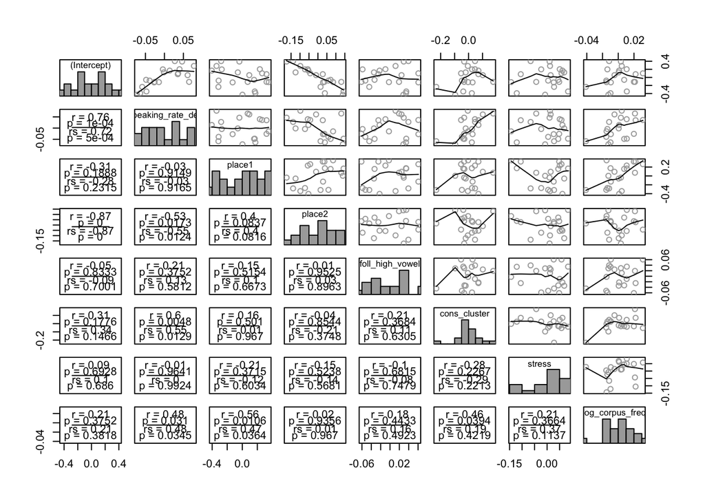

```r
pairscor.fnc(ranef(vot_voiced_m3)$speaker)
```

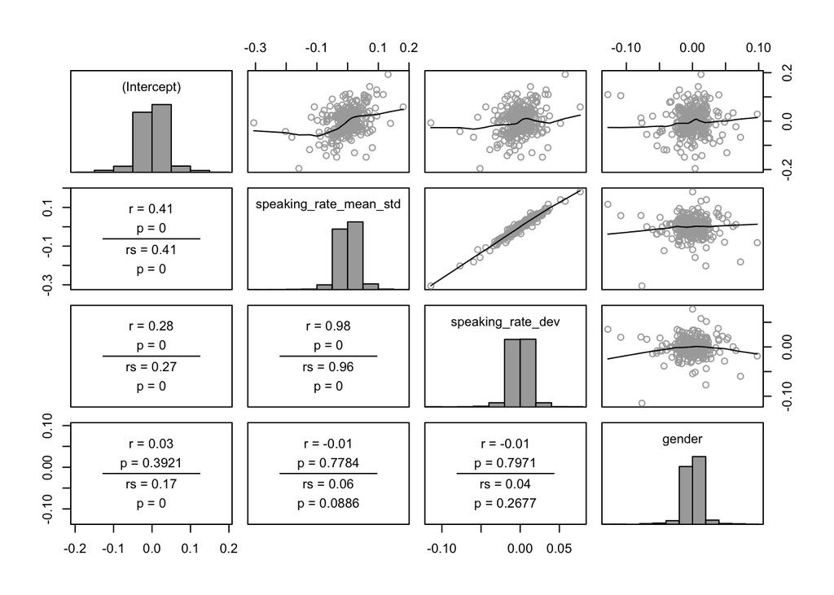

```r
pairscor.fnc(ranef(vot_voiced_m3)$word)
```

By-speaker random slopes for frequency, cons_cluster have the highest correlations with other terms ($r=0.4$–0.6). In each case, the highest correlations are with terms in the block with correlations (intercept, `speaking_rate_dev`, `place`), so we must add the slope to this block.

Model with correlations for by-speaker frequency slope:

```r
vot_voiced_m4 <- update(vot_voiced_m0,  . ~ . -(1|speaker) - (1|word) +
         (1+speaking_rate_mean_std + speaking_rate_dev|word) +
         (0+gender||word) +
         (1+speaking_rate_dev+place1+place2+log_corpus_freq|speaker)  + (0+foll_high_vowel + cons_cluster + stress||speaker), control=lmerControl(optimizer = 'bobyqa'))
```

```
## boundary (singular) fit: see ?isSingular
```

This model is singular, due to overparametrized by-speaker random effects: in the random effects PCA, one component accounts for no variance:

```r
rePCA(vot_voiced_m4)$speaker
```

```
## Standard deviations (1, .., p=8):
## [1] 0.55208177 0.40877565 0.22120317 0.18920546 0.12039046 0.10073723 0.07378785
## [8] 0.00000000
##
## Rotation (n x k) = (8 x 8):
##            [,1]       [,2] [,3] [,4]       [,5] [,6]        [,7]        [,8]
## [1,] -0.6139209 -0.7041073    0    0 -0.2457625    0  0.24433111 -0.08507204
## [2,] -0.0736300 -0.1321203    0    0 -0.2757497    0 -0.92189456 -0.22626391
## [3,]  0.7368135 -0.6431994    0    0  0.1062278    0  0.04418377 -0.17367749
## [4,]  0.2566886  0.1936660    0    0 -0.9052400    0  0.25146101 -0.11795097
## [5,]  0.0943224 -0.1885873    0    0 -0.1811605    0 -0.15883288  0.94736006
## [6,]  0.0000000  0.0000000    0    0  0.0000000    1  0.00000000  0.00000000
## [7,]  0.0000000  0.0000000    1    0  0.0000000    0  0.00000000  0.00000000
## [8,]  0.0000000  0.0000000    0    1  0.0000000    0  0.00000000  0.00000000
```

We conclude that these correlation terms can’t be added to the model (too little data).

Model with correlations for by-speaker `cons_cluster` slope:

```r
vot_voiced_m5 <- update(vot_voiced_m0,  . ~ . -(1|speaker) - (1|word) +
         (1+speaking_rate_mean_std + speaking_rate_dev|word) +
         (0+gender||word) +
         (1+speaking_rate_dev+place1+place2+cons_cluster|speaker)  + (0+foll_high_vowel + log_corpus_freq + stress||speaker), control=lmerControl(optimizer = 'bobyqa'))
```

```
## boundary (singular) fit: see ?isSingular
```

This model is again singular, due to overparametrized by-speaker random effects, as we see in the random effects PCA:

```r
rePCA(vot_voiced_m5)$speaker
```

```
## Standard deviations (1, .., p=8):
## [1] 0.54371103 0.41832288 0.19819200 0.17938848 0.10360398 0.07572830 0.06988771
## [8] 0.00000000
##
## Rotation (n x k) = (8 x 8):
##             [,1]       [,2]       [,3] [,4] [,5]        [,6] [,7]        [,8]
## [1,] -0.65492362 -0.6369950 -0.1088709    0    0 -0.32773906    0 -0.21458491
## [2,] -0.08114949 -0.1457568  0.2731610    0    0  0.74112026    0 -0.59016398
## [3,]  0.70076095 -0.6823824 -0.2073148    0    0  0.00569803    0 -0.01662573
## [4,]  0.26752303  0.1358121  0.4874739    0    0 -0.58290206    0 -0.57669825
## [5,] -0.04307350 -0.2981638  0.7955626    0    0  0.05933461    0  0.52230499
## [6,]  0.00000000  0.0000000  0.0000000    0    1  0.00000000    0  0.00000000
## [7,]  0.00000000  0.0000000  0.0000000    0    0  0.00000000    1  0.00000000
## [8,]  0.00000000  0.0000000  0.0000000    1    0  0.00000000    0  0.00000000
```

Our final model is thus `vot_voiced_m3`.

Note how similar the results for fixed and random-effect terms (except correlations, of course) are for the two models which we could have stopped at:

- `vot_voiced_m1`: uncorrelated random effects
- `vot_voiced_m3`: + motivated correlation terms

# 10 Cleaning up

Save all objects:

```r
save.image(file="objects/convergence_appendix_mods.RData")
```